# Project Description: Mining Starbucks customer data - predicting offer success

1. Introduction and motivation
2. Installation
3. Files in the repository
4. Results
5. Details
6. Data Sets

### Introduction and motivation

This project aims to answer a set of questions based on the provided datasets from Starbucks: transactions, customer profiles and offer types. The main question we will ask, and around which the whole project revolves, is:

```
            What is the likelihood that a customer will respond to a certain offer?
```

Other questions to be answered are:

About the offers:

- Which one is the longest offer duration?
- Which one is the most rewarding offer?

About the customers:

- What is the gender distribution?
- How different genders are distributed with respect to income?
- How different genders are distributed with respect to age?
- What is the distribution of new memberships along time?

About the transactions:

- Which offers are preferred according to gender?
- Which offers are preferred according to income?
- Which offers are preferred according to age?
- Which offers are preferred according to date of becoming a member?
- Which are the most successful offers?
- Which are the most profitable offers?
- Which are the most profitable offers between informational?
- How much money was earned in total with offers Vs. without offers?

**The motivation is to improve targeting of offers to Starbucks' customers to increase revenue.**

**Process and results presented in this blogpost.**

We will follow the [CRISP-DM](https://en.wikipedia.org/wiki/Cross-industry_standard_process_for_data_mining) data science process standard for accomplishing the data analysis at hand.

### Installation

**Packages needed** Wrangling and cleansing: pandas, json, pickle Math: numpy, math, scipy Visualization: matplotlib, IPython, Progress bar: tim, progressbar ML: sklearn

### Files in the repository

1. data folder: 1.1 portfolio.json - containing offer ids and meta data about each offer (duration, type, etc.) 1.2 profile.json - demographic data for each customer 1.3 transcript.json - records for transactions, offers received, offers viewed, and offers completed
2. Starbucks_Capstone_notebook.ipynb: Contains an executable python notebook for your to execute and modify as you wish.
3. Starbucks_Capstone_notebook.html: If you are not interested in extending or executing the code yourself, you may open this file and read through the anaylsis.
4. Other pickle files saving the datasets and models.

### Results

The best model to predict if an offer will be successful is Gradient Boosting. However, 70% is not such a high accuracy, better than human though. Grid search did not show much improvements, so furtehr tunning should be carried out. We saw that the learning rate went from 0.1 to 0.5, while the rest of parameters stayed the same. The enxt logical step would be to try with a learning rate of 0.75 (as 1 was not chosen) and try to change other parameters.

### Details

This data set contains simulated data that mimics customer behavior on the Starbucks rewards mobile app. Once every few days, Starbucks sends out an offer to users of the mobile app. An offer can be merely an advertisement for a drink or an actual offer such as a discount or BOGO (buy one get one free). Some users might not receive any offer during certain weeks.

Not all users receive the same offer, and that is the challenge to solve with this data set.

Your task is to combine transaction, demographic and offer data to determine which demographic groups respond best to which offer type. This data set is a simplified version of the real Starbucks app because the underlying simulator only has one product whereas Starbucks actually sells dozens of products.

Every offer has a validity period before the offer expires. As an example, a BOGO offer might be valid for only 5 days. You'll see in the data set that informational offers have a validity period even though these ads are merely providing information about a product; for example, if an informational offer has 7 days of validity, you can assume the customer is feeling the influence of the offer for 7 days after receiving the advertisement.

You'll be given transactional data showing user purchases made on the app including the timestamp of purchase and the amount of money spent on a purchase. This transactional data also has a record for each offer that a user receives as well as a record for when a user actually views the offer. There are also records for when a user completes an offer.

Keep in mind as well that someone using the app might make a purchase through the app without having received an offer or seen an offer.

#### Example

To give an example, a user could receive a discount offer buy 10 dollars get 2 off on Monday. The offer is valid for 10 days from receipt. If the customer accumulates at least 10 dollars in purchases during the validity period, the customer completes the offer.

However, there are a few things to watch out for in this data set. Customers do not opt into the offers that they receive; in other words, a user can receive an offer, never actually view the offer, and still complete the offer. For example, a user might receive the "buy 10 dollars get 2 dollars off offer", but the user never opens the offer during the 10 day validity period. The customer spends 15 dollars during those ten days. There will be an offer completion record in the data set; however, the customer was not influenced by the offer because the customer never viewed the offer.

#### Cleaning

This makes data cleaning especially important and tricky.

You'll also want to take into account that some demographic groups will make purchases even if they don't receive an offer. From a business perspective, if a customer is going to make a 10 dollar purchase without an offer anyway, you wouldn't want to send a buy 10 dollars get 2 dollars off offer. You'll want to try to assess what a certain demographic group will buy when not receiving any offers.

#### Advice

Because this is a capstone project, you are free to analyze the data any way you see fit. For example, you could build a machine learning model that predicts how much someone will spend based on demographics and offer type. Or you could build a model that predicts whether or not someone will respond to an offer. Or, you don't need to build a machine learning model at all. You could develop a set of heuristics that determine what offer you should send to each customer (i.e., 75 percent of women customers who were 35 years old responded to offer A vs 40 percent from the same demographic to offer B, so send offer A).

### Data Sets

This data set contains simulated data that mimics customer behavior on the Starbucks rewards mobile app. Once every few days, Starbucks sends out an offer to users of the mobile app. An offer can be merely an advertisement for a drink or an actual offer such as a discount or BOGO (buy one get one free). Some users might not receive any offer during certain weeks.

The data is contained in three files:

```
portfolio.json - containing offer ids and meta data about each offer (duration, type, etc.)
profile.json - demographic data for each customer
transcript.json - records for transactions, offers received, offers viewed, and offers completed
```

# Mining Starbucks customer data - predicting purchasing likelihood

We will follow the [CRISP-DM](https://en.wikipedia.org/wiki/Cross-industry_standard_process_for_data_mining) data science process standard for accomplishing the data anaylsis at hand.

### 1. Business Understanding

The motivation is to improve targeting of offers to Starbucks customers to increase revenue. Our goal therefore is to find a relationship between customers and Starbucks offers based on purchasing patterns from the customers. Thus, we need to understand the customers included in the datasets, identify groups within them, and assign the best matching offers to these groups. Therefore, the main question we should answer is:

**What is the likelihood that a customer will respond to a certain offer?**

Having a model that predicts a customer's behavior will accomplish the goal of this project. During the data exploration, other questions related to customers and offers will be formulated, as tour understanding of the data will be increased.

### 2. Data Understanding

The goal of data understanding is to have an overview of what is in the datasets and already filter the data we need to answer the main question. After we filter the needed data, we will proceed to wrangle and clean the data to make modelling possible. After wrangling and cleaning, we will explore further the data to extract additional questions we could answer based on its new form.

### Metrics

We first need to define a set of metrics to be able to assess whether an offer suits a particular customer (assesing whether we answered the question correctly with our model).

We have a classification problem (customer-offer) and data to train a model. Thus, we we will use supervised learning models and use:

1. **Accuracy** (number of correct predictions divided by the total number of predictions),
2. **F-Score** with beta=0.5 ((1+beta^2)*Precision*Recall/(beta^2 * (Precision+Recall))) (F-score is used to combine precision (True_Positive/ (True_Positive+ False_Positive)) and recall(True_Positive / (True_Positive + False_Negative))).

The data seems balanced, but nonetheless, the F-score might come in handy to choose between top models in case accuracy are similar.

Definitions from [Medium blogpost](https://towardsdatascience.com/20-popular-machine-learning-metrics-part-1-classification-regression-evaluation-metrics-1ca3e282a2ce). And for a better understanding on precision and recall, [wikipedia](https://en.wikipedia.org/wiki/Precision_and_recall) does the job great!

#### Imports for data handling

```python
# Data cleaning and wrangling
import pandas as pd
import json
import pickle

# Math
import numpy as np
import math
from scipy.stats import wasserstein_distance

# Visualization
import matplotlib.pyplot as plt
from IPython.display import display, Math, Latex
%matplotlib inline
%pylab inline

# progress bar
import progressbar
from time import sleep
from time import time

# ML
from sklearn.model_selection import train_test_split

# disable warning for mapping
pd.options.mode.chained_assignment = None  # default='warn'
```

#### DataSets

The data is contained in three files:

- portfolio.json - containing offer ids and meta data about each offer (duration, type, etc.)
- profile.json - demographic data for each customer
- transcript.json - records for transactions, offers received, offers viewed, and offers completed

#### Offer types: portfolio.json

- id (string) - offer id
- offer_type (string) - type of offer ie BOGO, discount, informational
- difficulty (int) - minimum required spend to complete an offer
- reward (int) - reward given for completing an offer
- duration (int) - time for offer to be open, in days
- channels (list of strings)

```python
# read in the json files
portfolio = pd.read_json('data/portfolio.json', orient='records', lines=True)
```

```python
portfolio
```

|  | reward | channels | difficulty | duration | offer_type | id |
| --- | --- | --- | --- | --- | --- | --- |
| 0 | 10 | [email, mobile, social] | 10 | 7 | bogo | ae264e3637204a6fb9bb56bc8210ddfd |
| 1 | 10 | [web, email, mobile, social] | 10 | 5 | bogo | 4d5c57ea9a6940dd891ad53e9dbe8da0 |
| 2 | 0 | [web, email, mobile] | 0 | 4 | informational | 3f207df678b143eea3cee63160fa8bed |
| 3 | 5 | [web, email, mobile] | 5 | 7 | bogo | 9b98b8c7a33c4b65b9aebfe6a799e6d9 |
| 4 | 5 | [web, email] | 20 | 10 | discount | 0b1e1539f2cc45b7b9fa7c272da2e1d7 |
| 5 | 3 | [web, email, mobile, social] | 7 | 7 | discount | 2298d6c36e964ae4a3e7e9706d1fb8c2 |
| 6 | 2 | [web, email, mobile, social] | 10 | 10 | discount | fafdcd668e3743c1bb461111dcafc2a4 |
| 7 | 0 | [email, mobile, social] | 0 | 3 | informational | 5a8bc65990b245e5a138643cd4eb9837 |
| 8 | 5 | [web, email, mobile, social] | 5 | 5 | bogo | f19421c1d4aa40978ebb69ca19b0e20d |
| 9 | 2 | [web, email, mobile] | 10 | 7 | discount | 2906b810c7d4411798c6938adc9daaa5 |

```python
print('Size:', portfolio.size, 'Shape:', portfolio.shape)
print('\n')
print('Portfolio Information')
print(portfolio.info())
print('\n')
print('Null values [%]')
print(portfolio.isnull().sum()/portfolio.shape[0])
print('\n')
print('Duplicated values')
# We first need toconvert the channels attribute temporaly to a string insead of a list of strings. Otherwsie "unhashable"
df_temp = portfolio
df_temp = df_temp.astype({"channels": str})
print(df_temp.duplicated().sum())
print('\n')
print('Portfolio Description')
print(portfolio.describe())
print('\n')
print('Skewness: ', portfolio.skew())
```

```
Size: 60 Shape: (10, 6)


Portfolio Information
<class 'pandas.core.frame.DataFrame'>
RangeIndex: 10 entries, 0 to 9
Data columns (total 6 columns):
 #   Column      Non-Null Count  Dtype
---  ------      --------------  -----
 0   reward      10 non-null     int64
 1   channels    10 non-null     object
 2   difficulty  10 non-null     int64
 3   duration    10 non-null     int64
 4   offer_type  10 non-null     object
 5   id          10 non-null     object
dtypes: int64(3), object(3)
memory usage: 608.0+ bytes
None


Null values [%]
reward        0.0
channels      0.0
difficulty    0.0
duration      0.0
offer_type    0.0
id            0.0
dtype: float64


Duplicated values
0


Portfolio Description
          reward  difficulty   duration
count  10.000000   10.000000  10.000000
mean    4.200000    7.700000   6.500000
std     3.583915    5.831905   2.321398
min     0.000000    0.000000   3.000000
25%     2.000000    5.000000   5.000000
50%     4.000000    8.500000   7.000000
75%     5.000000   10.000000   7.000000
max    10.000000   20.000000  10.000000


Skewness:  reward        0.665459
difficulty    0.669945
duration      0.233151
dtype: float64
```

1. There are 10 types of offers for one product (as specified in the descrition) and are characterized by 6 attributes.
2. They are a mixture of integers (3) and strings (2) and arrays of strings (1).
3. There are no null values.
4. The offers have an average reward of 4, a duration of 6.5 days and a difficulty of 7.7.
5. The domain of the integer attributes is small (0-20).
6. The median (50% percentile) is not too far from the mean, thus, the integer columms should be somewhat balanced.
7. Cross checking with the skewness, we see that duration is balanced, while reward and difficulty are somwhat inbalance, but it is not extreme whatsoever.
8. It is a very small datasets interms of bytes.
9. We clearly see the types of categories that channels and offer_type have.
10. There are no duplicated values

To answer the proposed question, we need every data point of this dataset, as it characterizes all types of offers.

#### Customer demographics: profile.json

- age (int) - age of the customer
- became_member_on (int) - date when customer created an app account
- gender (str) - gender of the customer (note some entries contain 'O' for other rather than M or F)
- id (str) - customer id
- income (float) - customer's income

```python
# read in the json files
profile = pd.read_json('data/profile.json', orient='records', lines=True)
```

```python
profile.head()
```

|  | gender | age | id | became_member_on | income |
| --- | --- | --- | --- | --- | --- |
| 0 | None | 118 | 68be06ca386d4c31939f3a4f0e3dd783 | 20170212 | NaN |
| 1 | F | 55 | 0610b486422d4921ae7d2bf64640c50b | 20170715 | 112000.0 |
| 2 | None | 118 | 38fe809add3b4fcf9315a9694bb96ff5 | 20180712 | NaN |
| 3 | F | 75 | 78afa995795e4d85b5d9ceeca43f5fef | 20170509 | 100000.0 |
| 4 | None | 118 | a03223e636434f42ac4c3df47e8bac43 | 20170804 | NaN |

```python
print('Size:', profile.size, 'Shape:', profile.shape)
print('\n')
print('Portfolio Information')
print(profile.info())
print('\n')
print('Null values [%]')
print(profile.isnull().sum()/profile.shape[0])
print('\n')
print('Duplicated values')
print(profile.duplicated().sum())
print('\n')
print('Portfolio Description')
print(profile.describe())
print('\n')
print('Skewness: ', profile.skew())
```

```
Size: 85000 Shape: (17000, 5)


Portfolio Information
<class 'pandas.core.frame.DataFrame'>
RangeIndex: 17000 entries, 0 to 16999
Data columns (total 5 columns):
 #   Column            Non-Null Count  Dtype
---  ------            --------------  -----
 0   gender            14825 non-null  object
 1   age               17000 non-null  int64
 2   id                17000 non-null  object
 3   became_member_on  17000 non-null  int64
 4   income            14825 non-null  float64
dtypes: float64(1), int64(2), object(2)
memory usage: 664.2+ KB
None


Null values [%]
gender              0.127941
age                 0.000000
id                  0.000000
became_member_on    0.000000
income              0.127941
dtype: float64


Duplicated values
0


Portfolio Description
                age  became_member_on         income
count  17000.000000      1.700000e+04   14825.000000
mean      62.531412      2.016703e+07   65404.991568
std       26.738580      1.167750e+04   21598.299410
min       18.000000      2.013073e+07   30000.000000
25%       45.000000      2.016053e+07   49000.000000
50%       58.000000      2.017080e+07   64000.000000
75%       73.000000      2.017123e+07   80000.000000
max      118.000000      2.018073e+07  120000.000000


Skewness:  age                 0.761858
became_member_on   -0.900457
income              0.402005
dtype: float64
```

As noted for the previous dataset, it is clear that we will need all these data to cluster customers and find their best fitting offer matches.

#### Transactions: transcript.json

- event (str) - record description (ie transaction, offer received, offer viewed, etc.)
- person (str) - customer id
- time (int) - time in hours since start of test. The data begins at time t=0
- value - (dict of strings) - either an offer id or transaction amount depending on the record

```python
# read in the json files
transcript = pd.read_json('data/transcript.json', orient='records', lines=True)
```

```python
transcript.head()
```

|  | person | event | value | time |
| --- | --- | --- | --- | --- |
| 0 | 78afa995795e4d85b5d9ceeca43f5fef | offer received | {'offer id': '9b98b8c7a33c4b65b9aebfe6a799e6d9'} | 0 |
| 1 | a03223e636434f42ac4c3df47e8bac43 | offer received | {'offer id': '0b1e1539f2cc45b7b9fa7c272da2e1d7'} | 0 |
| 2 | e2127556f4f64592b11af22de27a7932 | offer received | {'offer id': '2906b810c7d4411798c6938adc9daaa5'} | 0 |
| 3 | 8ec6ce2a7e7949b1bf142def7d0e0586 | offer received | {'offer id': 'fafdcd668e3743c1bb461111dcafc2a4'} | 0 |
| 4 | 68617ca6246f4fbc85e91a2a49552598 | offer received | {'offer id': '4d5c57ea9a6940dd891ad53e9dbe8da0'} | 0 |

```python
print('Size:', transcript.size, 'Shape:', transcript.shape)
print('\n')
print('Portfolio Information')
print(transcript.info())
print('\n')
print('Null values [%]')
print(transcript.isnull().sum()/transcript.shape[0])
print('\n')
print('Duplicated values')
print(profile.duplicated().sum())
print('\n')
print('Portfolio Description')
print(transcript.describe())
print('\n')
print('Skewness: ', transcript.skew())
```

```
Size: 1226136 Shape: (306534, 4)


Portfolio Information
<class 'pandas.core.frame.DataFrame'>
RangeIndex: 306534 entries, 0 to 306533
Data columns (total 4 columns):
 #   Column  Non-Null Count   Dtype
---  ------  --------------   -----
 0   person  306534 non-null  object
 1   event   306534 non-null  object
 2   value   306534 non-null  object
 3   time    306534 non-null  int64
dtypes: int64(1), object(3)
memory usage: 9.4+ MB
None


Null values [%]
person    0.0
event     0.0
value     0.0
time      0.0
dtype: float64


Duplicated values
0


Portfolio Description
                time
count  306534.000000
mean      366.382940
std       200.326314
min         0.000000
25%       186.000000
50%       408.000000
75%       528.000000
max       714.000000


Skewness:  time   -0.318927
dtype: float64
```

Let us check the category types of event, as they are not compeltly described in the project description.

```python
transcript['event'].unique()
```

```
array(['offer received', 'offer viewed', 'transaction', 'offer completed'],
      dtype=object)
```

The chronological order therefore would be:

1. offer received
2. offer viewed
3. transaction
4. offer completed

With respect to 'value', we will need to clean the data to extact more information. But the amount is most probably attached when the event is 'transaction' and an offer 'id' otherwise.

As with the rest of datasets, we need all information from this one as wel in order to answer the main question.

#### Overall Observations

Looking how we need all data points for answering our question (there is no attribute that we could delete without further knowledge), and that everything has the potential to be correlated, we will merge the 3 datasets into one after wrangling and cleaning.

### 3. Data Preparation

We will follow [Tidy Data from Hadley Wickham](https://vita.had.co.nz/papers/tidy-data.pdf) to prepare the datasets.

We will visualize further each dataset and come up with further questions that we also could answer. We will also indicate the data we need to answer each. There will be an exploration section after wrangling and cleansing.

#### PORTFOLIO

```python
portfolio = pd.read_json('data/portfolio.json', orient='records', lines=True)
portfolio
```

|  | reward | channels | difficulty | duration | offer_type | id |
| --- | --- | --- | --- | --- | --- | --- |
| 0 | 10 | [email, mobile, social] | 10 | 7 | bogo | ae264e3637204a6fb9bb56bc8210ddfd |
| 1 | 10 | [web, email, mobile, social] | 10 | 5 | bogo | 4d5c57ea9a6940dd891ad53e9dbe8da0 |
| 2 | 0 | [web, email, mobile] | 0 | 4 | informational | 3f207df678b143eea3cee63160fa8bed |
| 3 | 5 | [web, email, mobile] | 5 | 7 | bogo | 9b98b8c7a33c4b65b9aebfe6a799e6d9 |
| 4 | 5 | [web, email] | 20 | 10 | discount | 0b1e1539f2cc45b7b9fa7c272da2e1d7 |
| 5 | 3 | [web, email, mobile, social] | 7 | 7 | discount | 2298d6c36e964ae4a3e7e9706d1fb8c2 |
| 6 | 2 | [web, email, mobile, social] | 10 | 10 | discount | fafdcd668e3743c1bb461111dcafc2a4 |
| 7 | 0 | [email, mobile, social] | 0 | 3 | informational | 5a8bc65990b245e5a138643cd4eb9837 |
| 8 | 5 | [web, email, mobile, social] | 5 | 5 | bogo | f19421c1d4aa40978ebb69ca19b0e20d |
| 9 | 2 | [web, email, mobile] | 10 | 7 | discount | 2906b810c7d4411798c6938adc9daaa5 |

#### Data wrangling

1. reward: no change
2. Channels: create 4 new columns with binary values for the training of the model
3. difficulty: no change
4. duration: change to hours to be on the same units as the other dataset
5. offer_type: reate 3 new columns with binary values ofr the trainig of the model
6. id: Convert it into an increasing integer ID for easier representation later

It is common to all that for better understand-ability, we will rename the attributes in a way that we can know the units of the column and that we can link the datasets as we already surmised.

###### Rename columns

```python
# Renaming columns
portfolio.columns = ['reward_[$]', 'channels', 'difficulty_[$]', 'duration_[h]', 'offer_type', 'offer_id']
```

###### convert to hours the duration column

```python
portfolio['duration_[h]'] = portfolio['duration_[h]'].apply(lambda x: x * 24)
```

###### Rename the offer ids

```python
# We create a dictionary with offer ids we will need to save for later use
offer_id_dict = portfolio['offer_id'].to_dict()

# We invert the key-value pairs so the hash is in the key position
offer_id_dict = {v: k for k, v in offer_id_dict.items()}

# We save it as a pickle file
with open('offer_id_dict.pickle', 'wb') as handle:
    pickle.dump(offer_id_dict, handle, protocol=pickle.HIGHEST_PROTOCOL)
```

```python
# Now we convert the column: https://stackoverflow.com/questions/20250771/remap-values-in-pandas-column-with-a-dict
portfolio = portfolio.replace({"offer_id": offer_id_dict})
```

###### Create new columns based on offer_type

```python
# We save the dummy column of offer type (convinient for later analysis)
offer_type_dummy = portfolio['offer_type']
```

```python
# Get dummies: https://pandas.pydata.org/pandas-docs/stable/reference/api/pandas.get_dummies.html
portfolio = pd.get_dummies(portfolio, prefix=['offer_type'], columns=['offer_type'])
```

```python
# We concat the dummy column
portfolio = pd.concat([portfolio, offer_type_dummy], axis=1)
```

###### Create new columns based on event

```python
# Get teh dummie variables: https://stackoverflow.com/questions/29034928/pandas-convert-a-column-of-list-to-dummies
channel_dummies = pd.get_dummies(portfolio['channels'].apply(pd.Series).stack(), prefix='channel').sum(level=0)

# We drop the old column and concat the new one
portfolio.drop(columns=['channels'], inplace=True)

# We concat the new set of columns
portfolio = pd.concat([portfolio, channel_dummies], axis=1)
```

#### Data cleansing

Undesirable value detection:

1. Missing values: No
2. Duplicates: No
3. Incorrect values: No. We trust Starbucks that the offer portfolio is correct, as there is no way for us to verify it.
4. Irrelevant: Each row is relevant becuase it belongs to a distinct offer we will have to match with customers. The dataset is not large, we do not need to use PCA to know that the channel_email column does not explain any variability (all values are the same), so we can drop it.

Measures:

1. Replace: No
2. Modify: No
3. Delete: channel_email

###### Irrelevancy

```python
# We delete the email channel column
portfolio.drop(columns=['channel_email'], inplace=True)
```

###### We save the dataframe as a pickle file

```python
portfolio.to_pickle("./portfolio.pkl")
```

#### Data exploration

```python
portfolio
```

|  | reward_[$] | difficulty_[$] | duration_[h] | offer_id | offer_type_bogo | offer_type_discount | offer_type_informational | offer_type | channel_mobile | channel_social | channel_web |
| --- | --- | --- | --- | --- | --- | --- | --- | --- | --- | --- | --- |
| 0 | 10 | 10 | 168 | 0 | 1 | 0 | 0 | bogo | 1 | 1 | 0 |
| 1 | 10 | 10 | 120 | 1 | 1 | 0 | 0 | bogo | 1 | 1 | 1 |
| 2 | 0 | 0 | 96 | 2 | 0 | 0 | 1 | informational | 1 | 0 | 1 |
| 3 | 5 | 5 | 168 | 3 | 1 | 0 | 0 | bogo | 1 | 0 | 1 |
| 4 | 5 | 20 | 240 | 4 | 0 | 1 | 0 | discount | 0 | 0 | 1 |
| 5 | 3 | 7 | 168 | 5 | 0 | 1 | 0 | discount | 1 | 1 | 1 |
| 6 | 2 | 10 | 240 | 6 | 0 | 1 | 0 | discount | 1 | 1 | 1 |
| 7 | 0 | 0 | 72 | 7 | 0 | 0 | 1 | informational | 1 | 1 | 0 |
| 8 | 5 | 5 | 120 | 8 | 1 | 0 | 0 | bogo | 1 | 1 | 1 |
| 9 | 2 | 10 | 168 | 9 | 0 | 1 | 0 | discount | 1 | 0 | 1 |

We now habve tidy data, each record is an observation, we only have one observation type (offer), the values are in the cells and all variable names are in the columns (except for the column offer_type which is left there for visualization purposes later, it will be deleted)

This is the portfolio dataset by itself, the questions that we could make are solely related to the types of offers Starbucks has. It is not so interesting given the small size of the dataset, looking at the layout, one can have a feeling for the data already. There are 4 bogo offer types, 4 discount types and 2 informationa. There is only one offer that is using one channel and is of discount type. The rest use at least 2 channels. Let us set a few further questions:

1. Which one is the longest offer duration?
2. Which one is the most rewarding offer? This one however is interesting, but we cannot answer it yet:

###### Which one is the longest offer duration?

```python
max_duration_offers = portfolio.loc[portfolio['duration_[h]'] == portfolio['duration_[h]'].max()].index
print('The maximum duration offers are', portfolio.iloc[max_duration_offers]['offer_id'].iloc[0], 'and', \
                                         portfolio.iloc[max_duration_offers]['offer_id'].iloc[1])
print('With a duration of:', portfolio['duration_[h]'].max(), 'h')
```

```
The maximum duration offers are 4 and 6
With a duration of: 240 h
```

###### Which one is the most rewarding offer?

```python
max_reward_offers = portfolio.loc[portfolio['reward_[$]'] == portfolio['reward_[$]'].max()].index
print('The most rewarding offers are', portfolio.iloc[max_reward_offers]['offer_id'].iloc[0], 'and', \
                                       portfolio.iloc[max_reward_offers]['offer_id'].iloc[1])
print('With a reward of:', portfolio['reward_[$]'].max(), '$')
```

```
The most rewarding offers are 0 and 1
With a reward of: 10 $
```

However, a question that is interesting but that we cannot yet answer with this data (we need to use the other datasets as well), is what are the features of an offer that explain better which offer aligns better with a user.

#### PROFILE

```python
# read in the json files
profile = pd.read_json('data/profile.json', orient='records', lines=True)
profile.head()
```

|  | gender | age | id | became_member_on | income |
| --- | --- | --- | --- | --- | --- |
| 0 | None | 118 | 68be06ca386d4c31939f3a4f0e3dd783 | 20170212 | NaN |
| 1 | F | 55 | 0610b486422d4921ae7d2bf64640c50b | 20170715 | 112000.0 |
| 2 | None | 118 | 38fe809add3b4fcf9315a9694bb96ff5 | 20180712 | NaN |
| 3 | F | 75 | 78afa995795e4d85b5d9ceeca43f5fef | 20170509 | 100000.0 |
| 4 | None | 118 | a03223e636434f42ac4c3df47e8bac43 | 20170804 | NaN |

#### Data wrangling

1. age: No changes
2. became_member_on: transform into date and time
3. gender: Create dummy variables with M, F, O, and missing_gender. We keep the missing values because they do not seem random, as income has the same number of missing values
4. id: transform it into an easier id to read
5. income: No changes

We will change the column names to add the units and proper names.

###### Understanding NaN records

```python
# Let us verify that the missing values of gender pair with the ones from income
(profile['gender'].isnull() == profile['income'].isnull()).value_counts()
```

```
True    17000
dtype: int64
```

There are no False values, therefore they match. Now let us check what types of values in age and became_member_on these outliers have.

```python
print('Here is the age from the discussed outliers')
print(profile[profile['gender'].isnull()]['age'].unique())
print('Here is the number of unique became_member_on values of the discussed outliers')
print(profile[profile['gender'].isnull()]['became_member_on'].nunique())
```

```
Here is the age from the discussed outliers
[118]
Here is the number of unique became_member_on values of the discussed outliers
950
```

```python
# Let us check how many unique values does age have
print('Age unique values', profile['age'].nunique())
# Let us check what is the maximum age of the records that do not have missing values
print('Maximum age of not outliers', profile[~profile['gender'].isnull()]['age'].max())
```

```
Age unique values 85
Maximum age of not outliers 101
```

From these data we understand that the age of the outliers (records of missing valzes) is in itself an outlier (duh!). Because the oldest person is 101. In data cleansing, we will replace 118 by the average age of the customers as age is not too skewed. If we leave it at 118, these records would be weighted higher, which is not desirable. We will do the same for the income, we will substitute the nan values with the average income, as that column was not too skewed as well. What is important for data wrangling (and this overlaps with cleansing) is that we will replace the missing values with a gender sampled from a distribution equal to the distribution of the non_missing values. This way we do not skew the column. Additionally, we will add another column called 'missing_gender', to add another layer of information about these outliers.

```python
# Let us check the number of became_member_on unique values
profile['became_member_on'].nunique()
```

```
1716
```

There are 950 unique values of became_member_on in the outlier records, which is more than half of the toal unique values in the dataset. Considering that the outliers constitute about 12% of the dataset, this diversity hints that these values are true.

###### Change column names

```python
profile.columns = ['gender', 'age', 'customer_id', 'became_member_on_[y-m-d]', 'income_[$]']
```

###### Transform become_member_on date and time

```python
profile['became_member_on_[y-m-d]'] =  pd.to_datetime(profile['became_member_on_[y-m-d]'], format='%Y%m%d')
```

###### Transform id into an easier id form

```python
# We create a dictionary with offer ids we will need to save for later use
customer_id_dict = profile['customer_id'].to_dict()

# We invert the key-value pairs so the hash is in the key position
customer_id_dict = {v: k for k, v in customer_id_dict.items()}

# We save it as a pickle file
with open('customer_id_dict.pickle', 'wb') as handle:
    pickle.dump(customer_id_dict, handle, protocol=pickle.HIGHEST_PROTOCOL)
```

```python
# Now we convert the column: https://stackoverflow.com/questions/20250771/remap-values-in-pandas-column-with-a-dict
profile = profile.replace({"customer_id": customer_id_dict})
```

###### Gender wrangling

First we create a new binary column indicating if the record had missing values

```python
# first we identify which type of missing values has gender
# We know the first value of gender is missing
print(type(profile['gender'].iloc[0]))
```

```
<class 'NoneType'>
```

```python
# Thus, we know we have to check with None
print(profile['gender'].iloc[0] is None)
print(profile['gender'].iloc[0] is np.nan)
```

```
True
False
```

```python
profile['missing_values'] = profile['gender'].apply(lambda x: 1 if x is None else 0)
```

Second, we assign M,F or O to the missing values according to the underlying distribution of gender

```python
# We also get the frecuencies and categories. It is a nnice trick becuase value_counts does not consider None values
number_None_values = profile['gender'].isnull().sum()
total_gender_counts = profile.shape[0] - number_None_values
frecuencies_gender = profile['gender'].value_counts() / total_gender_counts
print('Frecuencies in %:')
print(frecuencies_gender)
```

```
Frecuencies in %:
M    0.572277
F    0.413423
O    0.014300
Name: gender, dtype: float64
```

```python
# Secomf we replicate the disribution
profile['gender'] = profile['gender'].apply \
                (lambda x: np.random.choice(frecuencies_gender.index, p=frecuencies_gender.values) if x is None else x)
```

Third, we perofrm one hot encoding on gender

```python
# Save dummy variable for later (visualization
gender_dummy = profile['gender']
```

```python
# Get dummies: https://pandas.pydata.org/pandas-docs/stable/reference/api/pandas.get_dummies.html
profile = pd.get_dummies(profile, prefix=['gender'], columns=['gender'])
```

```python
profile = pd.concat([profile, gender_dummy], axis=1)
```

#### Data cleansing

Undesirable value detection:

1. Missing values: income. Gender was taken care by the wrangling step.
2. Duplicates: No
3. Incorrect values: age
4. Irrelevant:

Measures:

1. Replace: replace income nans with the average of the column. Replace the age of 118 with the average age.
2. Modify: no
3. Delete: gender_dummy column (AFTER EXPLORATION OF ALL THE DATSETS COMBINED)

###### We replace income nan values with the average income

```python
# We calculate the average income
mean_income = profile['income_[$]'].mean()
```

```python
# We know the first value of income is missing
print(type(profile['income_[$]'].iloc[0]))
```

```
<class 'numpy.float64'>
```

```python
# Let us check how we can identify this value
print(profile['income_[$]'].iloc[0] is None)
print(profile['income_[$]'].iloc[0] is np.nan)
print(pd.isna(profile['income_[$]'].iloc[0]))
```

```
False
False
True
```

```python
# We replace the nan values with the mean income
profile['income_[$]'] = profile['income_[$]'].apply(lambda x: mean_income if pd.isna(x) else x)
```

###### We replace the 118 values with the average age (we truncate it)

```python
# We get the mean age
mean_age = int(profile['age'].mean())
```

```python
# We replace the 118 values by the mean
profile['age'] = profile['age'].apply(lambda x: mean_age if x == 118 else x)
```

#### Data exploration

```python
profile
```

|  | age | customer_id | became_member_on_[y-m-d] | income_[$] | missing_values | gender_F | gender_M | gender_O | gender |
| --- | --- | --- | --- | --- | --- | --- | --- | --- | --- |
| 0 | 62 | 0 | 2017-02-12 | 65404.991568 | 1 | 1 | 0 | 0 | F |
| 1 | 55 | 1 | 2017-07-15 | 112000.000000 | 0 | 1 | 0 | 0 | F |
| 2 | 62 | 2 | 2018-07-12 | 65404.991568 | 1 | 0 | 1 | 0 | M |
| 3 | 75 | 3 | 2017-05-09 | 100000.000000 | 0 | 1 | 0 | 0 | F |
| 4 | 62 | 4 | 2017-08-04 | 65404.991568 | 1 | 0 | 1 | 0 | M |
| ... | ... | ... | ... | ... | ... | ... | ... | ... | ... |
| 16995 | 45 | 16995 | 2018-06-04 | 54000.000000 | 0 | 1 | 0 | 0 | F |
| 16996 | 61 | 16996 | 2018-07-13 | 72000.000000 | 0 | 0 | 1 | 0 | M |
| 16997 | 49 | 16997 | 2017-01-26 | 73000.000000 | 0 | 0 | 1 | 0 | M |
| 16998 | 83 | 16998 | 2016-03-07 | 50000.000000 | 0 | 1 | 0 | 0 | F |
| 16999 | 62 | 16999 | 2017-07-22 | 82000.000000 | 0 | 1 | 0 | 0 | F |

17000 rows × 9 columns

We now habve tidy data, each record is an observation, we only have one observation type (customer), the values are in the cells and all variable names are in the columns (except for the column gender which is left there for visualization purposes later, it will be deleted)

Question we could answe:

1. What is the gender distribution?
2. How different genders are distributed with respect to income?
3. How different genders are distributed with respect to age?
4. What is the istribution of new memberships along time?

###### What is the gender distribution?

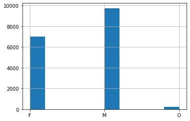

```python
profile['gender'].hist()
```

There are more males in the dataset

###### How different genders are distributed with respect to income?

```
array([[<matplotlib.axes._subplots.AxesSubplot object at 0x7ff658e3b950>,
      dtype=object)
```

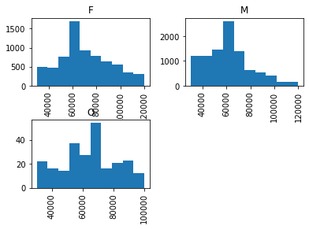

```python
profile['income_[$]'].hist(by=profile['gender'])
```

It seems that females and males have more or less the same income in this dataset. But it also seems that there is more women that earn abover the average than men. (The comparisons are not perfect becaus ethe number of women is around 3000 less than men, so the sample of women is less representative) It is worth extracting mroe insights as the distributions seem different. Let us check the [wassertein_distance](https://docs.scipy.org/doc/scipy/reference/generated/scipy.stats.wasserstein_distance.html)

```python
wasserstein_distance(profile.loc[profile['gender'] == 'F']['income_[$]'], profile.loc[profile['gender'] == 'M']['income_[$]'])
```

```
8824.90372841801
```

Indeed, the difference is prety high between the distributions of men and women.

```python
profile.loc[profile['gender'] == 'F']['income_[$]'].mean()
```

```
70566.20827461942
```

```python
women_mean_income = profile.loc[profile['gender'] == 'F']['income_[$]'].mean()
men_mean_income =  profile.loc[profile['gender'] == 'M']['income_[$]'].mean()
print('Mean salary for women is', women_mean_income)
print('Mean salary for men is', men_mean_income)
print('In this datase, women earn more money than men in average, by: ', women_mean_income-men_mean_income, '$')
```

```
Mean salary for women is 70566.20827461942
Mean salary for men is 61741.30454620141
In this datase, women earn more money than men in average, by:  8824.903728418009 $
```

```python
women_median_income = profile.loc[profile['gender'] == 'F']['income_[$]'].median()
men_median_income =  profile.loc[profile['gender'] == 'M']['income_[$]'].median()
print('Median salary for women is', women_median_income)
print('Median salary for men is', men_median_income)
print('In this dataset, however, the median is not so far from genders: ', women_median_income-men_median_income, '$')
```

[output not shown]

There are around 5000 men earning above $63k and around 3500 women earning mnore than $66k.

```python
women_std_income = profile.loc[profile['gender'] == 'F']['income_[$]'].std()
men_std_income =  profile.loc[profile['gender'] == 'M']['income_[$]'].std()
print('The std of the salary for women is', women_std_income)
print('The std of the salary for men is', men_std_income)
print('In this datase, however, the median is not so far from genders: ', women_std_income-men_std_income, '$')
```

```
The std of the salary for women is 20981.542952480755
The std of the salary for men is 18774.535245943607
In this datase, however, the median is not so far from genders:  2207.007706537148 $
```

The stds are high, and the one from women is higher (representative that there are less women in the sample than men)

###### How different genders distributed with respect to age?

```
array([[<matplotlib.axes._subplots.AxesSubplot object at 0x7ff658d067d0>,
      dtype=object)
```

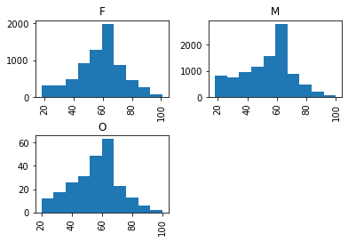

```python
profile['age'].hist(by=profile['gender'])
```

The histograms here are very similar. We could perform the same statictics as with income, but the histograms seem prety similar. Let us check the statistcial distance we used before:

```python
wasserstein_distance(profile.loc[profile['gender'] == 'F']['age'], profile.loc[profile['gender'] == 'M']['age'])
```

```
4.703738584474886
```

Indeed they are very similar.

###### What is the istribution of new memberships along time?

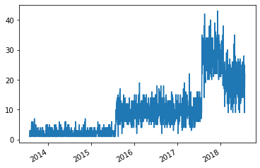

```python
profile['became_member_on_[y-m-d]'].value_counts().plot.line()
```

There are noticeable jumps every 2 years (half of 2015 and half 2017). Perhaps they correspond to new campaigns or improvements in the app. It is also interesting that in 2018, the number of new memberships dropped (first time), thus perhaps new competitors arrived into the market.

###### We save the dataframe as a pickle file

```python
profile.to_pickle("./profile.pkl")
```

#### TRANSCRIPT

```python
# read in the json files
transcript = pd.read_json('data/transcript.json', orient='records', lines=True)
transcript
```

|  | person | event | value | time |
| --- | --- | --- | --- | --- |
| 0 | 78afa995795e4d85b5d9ceeca43f5fef | offer received | {'offer id': '9b98b8c7a33c4b65b9aebfe6a799e6d9'} | 0 |
| 1 | a03223e636434f42ac4c3df47e8bac43 | offer received | {'offer id': '0b1e1539f2cc45b7b9fa7c272da2e1d7'} | 0 |
| 2 | e2127556f4f64592b11af22de27a7932 | offer received | {'offer id': '2906b810c7d4411798c6938adc9daaa5'} | 0 |
| 3 | 8ec6ce2a7e7949b1bf142def7d0e0586 | offer received | {'offer id': 'fafdcd668e3743c1bb461111dcafc2a4'} | 0 |
| 4 | 68617ca6246f4fbc85e91a2a49552598 | offer received | {'offer id': '4d5c57ea9a6940dd891ad53e9dbe8da0'} | 0 |
| ... | ... | ... | ... | ... |
| 306529 | b3a1272bc9904337b331bf348c3e8c17 | transaction | {'amount': 1.5899999999999999} | 714 |
| 306530 | 68213b08d99a4ae1b0dcb72aebd9aa35 | transaction | {'amount': 9.53} | 714 |
| 306531 | a00058cf10334a308c68e7631c529907 | transaction | {'amount': 3.61} | 714 |
| 306532 | 76ddbd6576844afe811f1a3c0fbb5bec | transaction | {'amount': 3.5300000000000002} | 714 |
| 306533 | c02b10e8752c4d8e9b73f918558531f7 | transaction | {'amount': 4.05} | 714 |

306534 rows × 4 columns

#### Data wrangling

1. person: replace the ids with the ones from the previous datasets. It can be connected to customer id
2. event: no changes. We will not use this column for prediction and it is useful to have it in this format for cleaning and wrangling and visualization.
3. time: no changes
4. value: make dict_keys a column and dict_values the values within. Once we do that, we transform offer ids into the easier to read ids defined before and leave the nans as they are (dealt with in cleansing). And the transaction one, we could replace the nans with a 0. For the offer ids with nans (meniang there is only an amount), we can replace the nan value with higher number than the last offer id, indicating that there was no offer. With reward, we set it to 0 for nans, we must check if this coincides with offer completed.

We will rename the columns so they can be combined later on. We have to think about how to collapse the records from a user into one row, so we can join the 3 datasets. This will require feature engineering. This last sentence is related ot the 'unsure' of points 2 and 4.

**In essence our final dataset should have pairs of customers and offers, together with a score for how well that offer did with the customer. The score can be binary, whether it worked or not. This score must be distilled from this transcript dataset**

###### Change column names

```python
# Renaming specific column: https://stackoverflow.com/questions/20868394/changing-a-specific-column-name-in-pandas-dataframe
transcript = transcript.rename(columns = {'person':'customer_id'})
```

###### Replace the person id with the ones from the dictionary mapping hashes to ints

```python
# Read back the dictionary
with open('customer_id_dict.pickle', 'rb') as handle:
    customer_id_dict = pickle.load(handle)
```

```python
# Now we convert the column: https://stackoverflow.com/questions/20250771/remap-values-in-pandas-column-with-a-dict
transcript = transcript.replace({"customer_id": customer_id_dict})
```

```python
# It tool a long time to execute the previous cell, let us do a check point
transcript.to_pickle("./transcript.pkl")
```

###### We transform the 'value' column into new columns for better wrangling

```python
# Ref: https://www.codegrepper.com/code-examples/python/dict+column+to+be+in+multiple+columns+python
value_dum = transcript['value'].apply(pd.Series)
transcript.to_pickle("./transcript.pkl")
value_dum
```

|  | offer id | amount | offer_id | reward |
| --- | --- | --- | --- | --- |
| 0 | 9b98b8c7a33c4b65b9aebfe6a799e6d9 | NaN | NaN | NaN |
| 1 | 0b1e1539f2cc45b7b9fa7c272da2e1d7 | NaN | NaN | NaN |
| 2 | 2906b810c7d4411798c6938adc9daaa5 | NaN | NaN | NaN |
| 3 | fafdcd668e3743c1bb461111dcafc2a4 | NaN | NaN | NaN |
| 4 | 4d5c57ea9a6940dd891ad53e9dbe8da0 | NaN | NaN | NaN |
| ... | ... | ... | ... | ... |
| 306529 | NaN | 1.59 | NaN | NaN |
| 306530 | NaN | 9.53 | NaN | NaN |
| 306531 | NaN | 3.61 | NaN | NaN |
| 306532 | NaN | 3.53 | NaN | NaN |
| 306533 | NaN | 4.05 | NaN | NaN |

306534 rows × 4 columns

offer id and offer_id should be the same. We will combine both columns. Reward might be a new column we have not accounted for in the beginning.

```python
# Let us check if this attribute is empty - It is not
value_dum['offer_id'].isnull().value_counts()
```

```
True     272955
False     33579
Name: offer_id, dtype: int64
```

```python
# Let us check if the values that are NOT missing in offer_id overlap with the ones NOT missing in offer id
print('Number of records where offer_id is NOT null', value_dum[~value_dum['offer_id'].isnull()].shape[0])
# If the number of missing values in 'offer id' is equal to the following number, then, while there is an overlap
# of both attributes in missing values, there is no overlap when there is content (we can assure this by means of
# the mehtod used to find this value thorugh pandas) - We count nan values of 'offer id' in a df where there are NO
# nans in 'offer_id'
value_dum[~value_dum['offer_id'].isnull()]['offer id'].isnull().value_counts()
```

```
Number of records where offer_id is NOT null 33579
```

```
True    33579
Name: offer id, dtype: int64
```

We thus conclude that the columns 'offer id' and 'offer_id' are the same (duh! - but one needs to cross check). We need to merge them.

```python
# Let us check how to identify the nan value
print(value_dum['offer_id'].iloc[-1] is None)
print(value_dum['offer_id'].iloc[-1] is np.nan)
print(pd.isna(value_dum['offer_id'].iloc[-1]))
```

```
False
False
True
```

```python
# Let us check if the values that are NOT missing in offer_id overlap with the ones NOT missing in offer id
value_dum['offer_id'] = value_dum.apply(lambda row: row['offer_id'] if pd.isna(row['offer id']) else row['offer id'], axis=1)
```

```python
# We drop the column from value_dum that is not useful
value_dum.drop(columns=['offer id'], inplace=True)

# We drop the old column and concat the new one
transcript.drop(columns=['value'], inplace=True)

# We concat the new set of columns
transcript = pd.concat([transcript, value_dum], axis=1)
```

###### We convert the offer id into the id we created before

```python
# Read back the dictionary
with open('offer_id_dict.pickle', 'rb') as handle:
    offer_id_dict = pickle.load(handle)
```

```python
# Now we convert the column: https://stackoverflow.com/questions/20250771/remap-values-in-pandas-column-with-a-dict
transcript = transcript.replace({"offer_id": offer_id_dict})
```

```python
# It tool a long time to execute the previous cell, let us do a check point
transcript.to_pickle("./transcript.pkl")
```

#### Data cleansing

Undesirable value detection:

1. Missing values: offer_id, amount, reward.
2. Duplicates: No
3. Incorrect values: offer ids are floats and not ints (probably becuase there are nans in the same column and somehow it affected the converion)
4. Irrelevant:

Measures:

1. Replace: offer_id nans with the value 10 (one above the last offer id). amount and reward nans will be replaced with a 0
2. Modify: offer_id into int again
3. Delete: none

###### Replace offer_id nans with the value 10

```python
# Let us check how to identify the nan value
print(transcript['offer_id'].iloc[-1] == None)
print(transcript['offer_id'].iloc[-1] is np.nan)
print(pd.isna(transcript['offer_id'].iloc[-1]))
print(transcript['offer_id'].iloc[-1] == 'nan')
```

```
False
False
True
False
```

```python
# We perform the change
transcript['offer_id'] = transcript['offer_id'].apply(lambda x: 10 if pd.isna(x) else x)
```

###### Convert offer_id into ints

```python
transcript = transcript.astype({"offer_id": int})
```

###### Replace amount nans with 0

```python
# Let us check how to identify the nan value
print(transcript['amount'].iloc[0] == None)
print(transcript['amount'].iloc[0] is np.nan)
print(pd.isna(transcript['amount'].iloc[0]))
print(transcript['amount'].iloc[0] == 'nan')
```

```
False
False
True
False
```

```python
# We perform the change
transcript['amount'] = transcript['amount'].apply(lambda x: 0 if pd.isna(x) else x)
```

###### Replace reward nans with 0

```python
# Let us check how to identify the nan value
print(transcript['reward'].iloc[0] == None)
print(transcript['reward'].iloc[0] is np.nan)
print(pd.isna(transcript['reward'].iloc[0]))
print(transcript['reward'].iloc[0] == 'nan')
```

```
False
False
True
False
```

```python
# We perform the change
transcript['reward'] = transcript['reward'].apply(lambda x: 0 if pd.isna(x) else x)
```

Let us change the column names with the appropiate units

```python
transcript.columns = ['customer_id', 'event', 'time_[h]', 'amount_[$]', 'offer_id', 'reward_[$]']
```

```python
# It tool a long time to execute the previous cell, let us do a check point
transcript.to_pickle("./transcript.pkl")
```

#### Feature engineering

```python
transcript = pd.read_pickle("./transcript.pkl")
transcript
```

|  | customer_id | event | time_[h] | amount_[$] | offer_id | reward_[$] |
| --- | --- | --- | --- | --- | --- | --- |
| 0 | 3 | offer received | 0 | 0.00 | 3 | 0.0 |
| 1 | 4 | offer received | 0 | 0.00 | 4 | 0.0 |
| 2 | 5 | offer received | 0 | 0.00 | 9 | 0.0 |
| 3 | 6 | offer received | 0 | 0.00 | 6 | 0.0 |
| 4 | 7 | offer received | 0 | 0.00 | 1 | 0.0 |
| ... | ... | ... | ... | ... | ... | ... |
| 306529 | 16959 | transaction | 714 | 1.59 | 10 | 0.0 |
| 306530 | 16964 | transaction | 714 | 9.53 | 10 | 0.0 |
| 306531 | 16979 | transaction | 714 | 3.61 | 10 | 0.0 |
| 306532 | 16987 | transaction | 714 | 3.53 | 10 | 0.0 |
| 306533 | 16994 | transaction | 714 | 4.05 | 10 | 0.0 |

306534 rows × 6 columns

We would like to combine all datasets to feed it to a model. The transcript dataset contains information about successful and unsuccessful offers, about the purchasing of the customers and about the rewards they have retrieved. We have two id columns, we can use them as foreign keys for the primary keys in the other two datasets to combine them. However, we cannot do that yet. We have to distill the data of the transcript data set to obtain the valuable information that will allow us to prognosticate if an offer will be accepted or not by an individual in the future. So first of all, how the ideal dataset would look like:

Offer id |...offer properties...| customer id | ...customer qualities... | success/no_success| profit | Viewed/Not viewed | Received/not_received

In order to get this datset, we need to assess the success of the offer. For that, we need to attach to the transcript dataset information from the portfolio: **offer duration, reward, difficulty** and type for data exploration.

- Success column: an offer is successful if a user has purchased the amount of the difficulty before the offer expires. thus, we need the duration and difficulty.
- Profit column: we coul dmake predictions and comparisons between groups with this column. for this we need: difficulty - reward.
- Viewed column: we need the event column of transaction
- Received column: we need the event column from transaction

Now let us start joining the transaction and the portfolio dataset

```python
# First, let us read again the portfolio
portfolio = pd.read_pickle("./portfolio.pkl")
```

We will add a virtual row for an offer with id 10, menaing that the offer does not exits. This will be attached to the rows of transacript where there was no offer made, but nonetheless there was a transaction.

```python
new_row = {'reward_[$]':[0],  'difficulty_[$]':[0], 'duration_[h]':[0], 'offer_id':[10], 'offer_type_bogo':[0], 'offer_type_discount':[0], \
           'offer_type_informational':[0], 'offer_type':'none', 'channel_mobile':[0], 'channel_social':[0], 'channel_web':[0]}
new_row = pd.DataFrame.from_dict(new_row)
portfolio = portfolio.append(new_row)
portfolio.to_pickle("./portfolio.pkl")
```

```python
transcript = pd.merge(transcript, portfolio, on='offer_id', how='left', sort=True, suffixes=('_trans', '_port'))
transcript = transcript.drop(columns=['offer_type_bogo', 'offer_type_discount', 'offer_type_informational', 'channel_mobile', 'channel_social', 'channel_web'])
```

(The offer_type attribute is only used for exploring raw data more easily, not needed to distill information)

Let us check that we still have all the rows from transaction data, i.e. the left join was successful - we see it is, it contains all the infromation.

```python
transcript.shape[0]
```

```
306534
```

We create a groubby object based on customer:

```python
customer_transactions = transcript.groupby(['customer_id'])
```

**Build dictionary to store the distilled values foolowing:**

Offer id |...offer properties...| customer id | ...customer qualities... | success/failure/Not_applicable | profit | Viewed/Not viewed | Received/not_received | effective_time

```python
ledger = {'customer_id': [], 'offer_id': [], 'received':[], 'viewed':[], 'completed':[], 'success': [], 'profit': []}
```

We will append to this ledger the values sequentially. 'success' will be categorical for now, as there could be 3 possibilities.

###### Fearure engineering algorithm

```python
# Let us get every customer id in a list
customer_ids = np.sort(transcript['customer_id'].unique())
# Let is get every offer id in a list,
offer_ids = np.sort(portfolio['offer_id'].unique())
# Let us get a list of informatinoal offer ids, as they behave differently
informational_offer_ids = [2, 7]
# this is the id for the added offer which is not an offer
non_offer_id = 10
```

We have in mind that the last offer id is a non offer. And that bogos and discounts act essenstially in the same manner.

Something to note is that a customer might not spend exactly the same amount of money needed to fulfill the offer, that is interesting but unfortunately, becuase offers overlap, you cannot really assign a profit to a offer-customer pair aside from the obvious one of difficulty - reward.

What we will do for the profit attribute: bogos and discount profit = difficulty- reward (Note that bogos will have a profit of 0) informational = the amount of dollars transacted in its period. We could also subtract the rewards obtained in that period, but it would only be useful if we added the other offers that were completed at the same time. This is out of scope for my questions. So the word profit for informational is not completely right. non_offer = the amount of dollars outside any offer period

Further considerations: For viewed or completed to happen, at least received has had to happen. There is no complete offer event outside the limit of time (offer leaves the app) There is no viewed offer event after the limit of time (offer leaves the app) There can be a viewed event after the complete event, so the offer is failure. Offers, be them the same or different, can overlap, which makes calculating which offer was successful trickier You can get the same offer in the same interval of time, you could get this combination: Received offer, received offer, complete offer, view offer, complete offer, view offer. You might think that at least one of the offers was successful, as view happens before complete at least once. That is in my view wrong. We assume that the same offer type comes sequentially, so the first time you see it, it belongs to the first offer you received, so that is why, in that sequence, both offers of the same type failed. We would need an identifier that says to which offer it belongs that helps you distinguish between views and completions of the same offer type. For the non-offers, we count only the gaps not influenced by an offer. Even if the offer was completed, we consider still it s influence.

The algorithm to find successful offers per customer (feature engineering):

1. Group by customer
2. Loop through each customer (for)
   1. Loop through each offer (for)
      1. Bogos and discounts: distill information about success, viewed, received, effective time and profit.
         1. Get the amount of received offers
         2. Iterate sequentially in time and event ordered, and find viewed or completed events. Depending on what was seen before, offers will have been successful or not
      2. Informational: idem, but there is no concept of success
      3. Non-offer: find the gaps where no offer was active and use these gaps to add the profit

*Profit is viewed at the end-customer of course, not considering how much money costs to sell the product.

*Transaction periods can overlap

```python
ledger = {'customer_id': [], 'offer_id': [], 'received':[], 'viewed':[], 'completed':[], 'success': [], 'profit': []}

# initialize the progress bar
bar = progressbar.ProgressBar(maxval=len(customer_ids), \
    widgets=[progressbar.Bar('=', '[', ']'), ' ', progressbar.Percentage()])

# For sorting the events later, as receive and view can happen in the same hour
event_sort = {'offer received':0,'offer viewed':1,'offer completed':2}

# start the loop through the customer transaction entries
bar.start()
for customer_id in customer_transactions.groups.keys():

    # We isolate the customers
    customer = customer_transactions.get_group(customer_id)

    # We get the offers received by the customer
    customer_offer_ids = customer['offer_id'].unique()

    # Loop thorugh customer offers
    for customer_offer_id in customer_offer_ids:

        # we filter the offer currently on in the loop
        offers = customer.loc[(customer['offer_id'] == customer_offer_id)]

        # The events at the same hour are not ordered like R - V - C, so we must order them
        offers['name_sort'] = offers['event'].map(event_sort)
        offers = offers.sort_values(['time_[h]', 'name_sort'], ascending=[True, True])

        # We focus in BOGOS AND DISCOUNTS
        if (customer_offer_id not in informational_offer_ids) and (customer_offer_id != non_offer_id):

            ledger_temp = {}
            received_offers = offers.loc[offers['event'] == 'offer received'].shape[0]
            for i in range(0, received_offers):

                ledger_temp[i] = {'received':1, 'viewed':0, 'completed':0, 'success': 0, 'profit': 0}

            # We loop through each row of the customer offer sub dataframe
            for index, row in offers.iterrows():

                if (row['event'] == 'offer viewed'):

                    for i in range(0, received_offers):

                        if (ledger_temp[i]['viewed'] == 0):

                            ledger_temp[i]['viewed'] = 1

                            break

                elif (row['event'] == 'offer completed'):

                    for i in range(0, received_offers):

                        if (ledger_temp[i]['completed'] == 0):

                            ledger_temp[i]['completed'] = 1

                            # only if it was viewed before was successful
                            if (ledger_temp[i]['viewed'] == 1):

                                ledger_temp[i]['success'] = 1
                                ledger_temp[i]['profit'] = row['difficulty_[$]'] - row['reward_[$]_port']

                            break

            for i in  range(0, received_offers):

                ledger['customer_id'].append(customer_id)
                ledger['offer_id'].append(customer_offer_id)
                ledger['received'].append(ledger_temp[i]['received'])
                ledger['viewed'].append(ledger_temp[i]['viewed'])
                ledger['completed'].append(ledger_temp[i]['completed'])
                ledger['success'].append(ledger_temp[i]['success'])
                ledger['profit'].append(ledger_temp[i]['profit'])

        # We focus on INFORMATIONAL
        elif (customer_offer_id != non_offer_id):

            ledger_temp = {}
            received_offer_counter = 0
            # We loop through each row of the customer offer sub dataframe
            for index, row in offers.iterrows():

                if (row['event'] == 'offer received'):

                    ledger_temp[received_offer_counter] = {'received':1, 'time_received':row['time_[h]'], 'viewed':0, 'completed':0, 'success': 0, 'profit': 0}
                    received_offer_counter += 1


                if (row['event'] == 'offer viewed'):

                    # Calculate profit
                    for i in range(0, received_offer_counter):

                        if ledger_temp[i]['viewed'] == 0:

                            ledger_temp[i]['viewed'] = 1

                            time_of_view = row['time_[h]']
                            expire_offer_time = ledger_temp[i]['time_received'] + row['duration_[h]']
                            profit = customer.loc[(customer['time_[h]'] >= time_of_view) & \
                                (customer['time_[h]'] <= expire_offer_time)]['amount_[$]'].sum()

                            ledger_temp[i]['profit'] = profit

                            # We consider it successful if the customer bought something
                            if profit > 0:

                                ledger_temp[i]['success'] = 1

                        break

            for i in  range(0, received_offer_counter):

                ledger['customer_id'].append(customer_id)
                ledger['offer_id'].append(customer_offer_id)
                ledger['received'].append(ledger_temp[i]['received'])
                ledger['viewed'].append(ledger_temp[i]['viewed'])
                ledger['completed'].append(ledger_temp[i]['completed'])
                ledger['success'].append(ledger_temp[i]['success'])
                ledger['profit'].append(ledger_temp[i]['profit'])

    # Order the offers properly
    # The events at the same hour are not ordered like R - V - C, so we must order them
    temp_customer = customer
    temp_customer['name_sort'] = temp_customer['event'].map(event_sort)
    temp_customer = temp_customer.sort_values(['time_[h]', 'name_sort'], ascending=[True, True])

    # We get the amount spent without offer influence
    # We find the first and last offer received
    start_times = []
    end_times = []
    offers_received = False
    for index, row in temp_customer.iterrows():

        if row['event'] == 'offer received':

            start_times.append(row['time_[h]'])
            end_times.append(row['time_[h]'] + row['duration_[h]'])
            offers_received = True

    if offers_received:

        time_gap_start = []
        time_gap_start.append(0)
        time_gap_end = []
        time_gap_end.append(start_times[0])
        for index in range(0, len(start_times)-1):

            if end_times[index] < start_times[index+1]:

                time_gap_start.append(end_times[index])
                time_gap_end.append(start_times[index+1])

        time_gap_start.append(end_times[-1])
        time_gap_end.append(temp_customer.iloc[-1]['time_[h]'])
        # Initialize the amount
        total_profit = 0
        for index in range(0, len(time_gap_start)):

            total_profit += temp_customer.loc[(temp_customer['time_[h]'] >= time_gap_start[index]) & \
                                       (temp_customer['time_[h]'] <= time_gap_end[index])]['amount_[$]'].sum()

    else:

        total_profit = temp_customer.loc[temp_customer['offer_id'] == non_offer_id]['amount_[$]'].sum()

    ledger['customer_id'].append(customer_id)
    ledger['offer_id'].append(non_offer_id)
    ledger['received'].append(0)
    ledger['viewed'].append(0)
    ledger['completed'].append(0)
    ledger['success'].append(0)
    ledger['profit'].append(total_profit)

    # initialize bool and total profit again
    offers_received = False
    total_profit = 0

    # progress bar
    bar.update(customer_id+1)
    sleep(0.1)

bar.finish()
```

```
[========================================================================] 100%
```

We save the ledger

```python
with open('ledger.pickle', 'wb') as handle:
    pickle.dump(ledger, handle, protocol=pickle.HIGHEST_PROTOCOL)
```

```python
Starbucks_ledger = pd.DataFrame.from_dict(ledger)
```

```python
Starbucks_ledger.to_pickle("./Starbucks_ledger.pkl")
```

#### FINAL STEP: Join all three datasets, Portfolio, profile and ledger

```python
# We read the wrangled and clean datasets
portfolio = pd.read_pickle("./portfolio.pkl")
profile = pd.read_pickle("./profile.pkl")
Starbucks_ledger = pd.read_pickle("./Starbucks_ledger.pkl")
```

```python
Starbucks_ledger
```

|  | customer_id | offer_id | received | viewed | completed | success | profit |
| --- | --- | --- | --- | --- | --- | --- | --- |
| 0 | 0 | 4 | 1 | 1 | 0 | 0 | 0.00 |
| 1 | 0 | 5 | 1 | 1 | 1 | 1 | 4.00 |
| 2 | 0 | 6 | 1 | 1 | 1 | 1 | 8.00 |
| 3 | 0 | 6 | 1 | 1 | 0 | 0 | 0.00 |
| 4 | 0 | 9 | 1 | 1 | 0 | 0 | 0.00 |
| ... | ... | ... | ... | ... | ... | ... | ... |
| 93272 | 16999 | 2 | 1 | 0 | 0 | 0 | 0.00 |
| 93273 | 16999 | 2 | 1 | 0 | 0 | 0 | 0.00 |
| 93274 | 16999 | 5 | 1 | 1 | 1 | 1 | 4.00 |
| 93275 | 16999 | 8 | 1 | 1 | 1 | 0 | 0.00 |
| 93276 | 16999 | 10 | 0 | 0 | 0 | 0 | 24.71 |

93277 rows × 7 columns

```python
Starbucks_final_df = pd.merge(Starbucks_ledger, profile, on='customer_id', how='left', sort=True, suffixes=('_led', '_pro'))
```

```python
Starbucks_final_df = pd.merge(Starbucks_final_df, portfolio, on='offer_id', how='left', sort=True, suffixes=('_led', '_port'))
```

###### We save the FINAL dataframe as a pickle file

```python
Starbucks_final_df.to_pickle("./Starbucks_final_df.pkl")
```

```python
Starbucks_final_df = pd.read_pickle("./Starbucks_final_df.pkl")
```

#### HERE IS THE BEAUTY:

```python
Starbucks_final_df
```

|  | customer_id | offer_id | received | viewed | completed | success | profit | age | became_member_on_[y-m-d] | income_[$] | ... | reward_[$] | difficulty_[$] | duration_[h] | offer_type_bogo | offer_type_discount | offer_type_informational | offer_type | channel_mobile | channel_social | channel_web |
| --- | --- | --- | --- | --- | --- | --- | --- | --- | --- | --- | --- | --- | --- | --- | --- | --- | --- | --- | --- | --- | --- |
| 0 | 3 | 0 | 1 | 1 | 1 | 1 | 0.00 | 75 | 2017-05-09 | 100000.000000 | ... | 10 | 10 | 168 | 1 | 0 | 0 | bogo | 1 | 1 | 0 |
| 1 | 7 | 0 | 1 | 0 | 0 | 0 | 0.00 | 62 | 2017-10-02 | 65404.991568 | ... | 10 | 10 | 168 | 1 | 0 | 0 | bogo | 1 | 1 | 0 |
| 2 | 10 | 0 | 1 | 1 | 1 | 1 | 0.00 | 62 | 2017-08-24 | 65404.991568 | ... | 10 | 10 | 168 | 1 | 0 | 0 | bogo | 1 | 1 | 0 |
| 3 | 11 | 0 | 1 | 1 | 0 | 0 | 0.00 | 62 | 2015-09-19 | 65404.991568 | ... | 10 | 10 | 168 | 1 | 0 | 0 | bogo | 1 | 1 | 0 |
| 4 | 13 | 0 | 1 | 1 | 1 | 0 | 0.00 | 61 | 2017-09-11 | 57000.000000 | ... | 10 | 10 | 168 | 1 | 0 | 0 | bogo | 1 | 1 | 0 |
| ... | ... | ... | ... | ... | ... | ... | ... | ... | ... | ... | ... | ... | ... | ... | ... | ... | ... | ... | ... | ... | ... |
| 93272 | 16995 | 10 | 0 | 0 | 0 | 0 | 13.27 | 45 | 2018-06-04 | 54000.000000 | ... | 0 | 0 | 0 | 0 | 0 | 0 | none | 0 | 0 | 0 |
| 93273 | 16996 | 10 | 0 | 0 | 0 | 0 | 19.51 | 61 | 2018-07-13 | 72000.000000 | ... | 0 | 0 | 0 | 0 | 0 | 0 | none | 0 | 0 | 0 |
| 93274 | 16997 | 10 | 0 | 0 | 0 | 0 | 12.93 | 49 | 2017-01-26 | 73000.000000 | ... | 0 | 0 | 0 | 0 | 0 | 0 | none | 0 | 0 | 0 |
| 93275 | 16998 | 10 | 0 | 0 | 0 | 0 | 24.81 | 83 | 2016-03-07 | 50000.000000 | ... | 0 | 0 | 0 | 0 | 0 | 0 | none | 0 | 0 | 0 |
| 93276 | 16999 | 10 | 0 | 0 | 0 | 0 | 24.71 | 62 | 2017-07-22 | 82000.000000 | ... | 0 | 0 | 0 | 0 | 0 | 0 | none | 0 | 0 | 0 |

93277 rows × 25 columns

```python
Starbucks_final_df.describe()
```

|  | customer_id | offer_id | received | viewed | completed | success | profit | age | income_[$] | missing_values | ... | gender_O | reward_[$] | difficulty_[$] | duration_[h] | offer_type_bogo | offer_type_discount | offer_type_informational | channel_mobile | channel_social | channel_web |
| --- | --- | --- | --- | --- | --- | --- | --- | --- | --- | --- | --- | --- | --- | --- | --- | --- | --- | --- | --- | --- | --- |
| count | 93277.000000 | 93277.000000 | 93277.000000 | 93277.000000 | 93277.000000 | 93277.000000 | 93277.000000 | 93277.000000 | 93277.000000 | 93277.000000 | ... | 93277.000000 | 93277.000000 | 93277.000000 | 93277.000000 | 93277.000000 | 93277.000000 | 93277.000000 | 93277.000000 | 93277.000000 | 93277.000000 |
| mean | 8499.395178 | 5.498933 | 0.817747 | 0.602539 | 0.359992 | 0.305263 | 4.991949 | 55.350794 | 65381.198519 | 0.128124 | ... | 0.013905 | 3.435852 | 6.302969 | 127.641241 | 0.326972 | 0.327444 | 0.163331 | 0.735540 | 0.489756 | 0.653977 |
| std | 4903.968525 | 3.355080 | 0.386055 | 0.489376 | 0.480000 | 0.460521 | 18.665452 | 16.439565 | 20186.211503 | 0.334229 | ... | 0.117097 | 3.475342 | 5.825448 | 76.903027 | 0.469110 | 0.469283 | 0.369669 | 0.441047 | 0.499898 | 0.475703 |
| min | 0.000000 | 0.000000 | 0.000000 | 0.000000 | 0.000000 | 0.000000 | 0.000000 | 18.000000 | 30000.000000 | 0.000000 | ... | 0.000000 | 0.000000 | 0.000000 | 0.000000 | 0.000000 | 0.000000 | 0.000000 | 0.000000 | 0.000000 | 0.000000 |
| 25% | 4253.000000 | 3.000000 | 1.000000 | 0.000000 | 0.000000 | 0.000000 | 0.000000 | 45.000000 | 51000.000000 | 0.000000 | ... | 0.000000 | 0.000000 | 0.000000 | 72.000000 | 0.000000 | 0.000000 | 0.000000 | 0.000000 | 0.000000 | 0.000000 |
| 50% | 8497.000000 | 6.000000 | 1.000000 | 1.000000 | 0.000000 | 0.000000 | 0.000000 | 58.000000 | 65404.991568 | 0.000000 | ... | 0.000000 | 2.000000 | 5.000000 | 120.000000 | 0.000000 | 0.000000 | 0.000000 | 1.000000 | 0.000000 | 1.000000 |
| 75% | 12742.000000 | 9.000000 | 1.000000 | 1.000000 | 1.000000 | 1.000000 | 4.000000 | 65.000000 | 76000.000000 | 0.000000 | ... | 0.000000 | 5.000000 | 10.000000 | 168.000000 | 1.000000 | 1.000000 | 0.000000 | 1.000000 | 1.000000 | 1.000000 |
| max | 16999.000000 | 10.000000 | 1.000000 | 1.000000 | 1.000000 | 1.000000 | 995.600000 | 101.000000 | 120000.000000 | 1.000000 | ... | 1.000000 | 10.000000 | 20.000000 | 240.000000 | 1.000000 | 1.000000 | 1.000000 | 1.000000 | 1.000000 | 1.000000 |

8 rows × 22 columns

```python
Starbucks_final_df.info()
```

```
<class 'pandas.core.frame.DataFrame'>
Int64Index: 93277 entries, 0 to 93276
Data columns (total 25 columns):
 #   Column                    Non-Null Count  Dtype
---  ------                    --------------  -----
 0   customer_id               93277 non-null  int64
 1   offer_id                  93277 non-null  int64
 2   received                  93277 non-null  int64
 3   viewed                    93277 non-null  int64
 4   completed                 93277 non-null  int64
 5   success                   93277 non-null  int64
 6   profit                    93277 non-null  float64
 7   age                       93277 non-null  int64
 8   became_member_on_[y-m-d]  93277 non-null  datetime64[ns]
 9   income_[$]                93277 non-null  float64
```

[output cut: 17 more lines]

#### Data wrangling

We will convert some of the coluimns into categorical values for better representation and to input into the model later.

We can delete the received column, as it does not provide usefiul information that we already do not know. If receive is 0, that means that there was no offer in the first, but we go that covered with offer id 10.

```python
Starbucks_final_df.drop(columns=['received'], inplace=True)
```

Now we will convert age into categories and then make dummy variables:

1. <25: young
2. 26-50: young_adult
3. 51-75: senior_adult
4. 75<: senior

```python
def select_age(age):

    if age <= 25:

        return 'young'

    elif age <= 50:

        return 'young_adult'

    elif age <= 75:

        return 'senior_adult'

    else:

        return 'senior'
```

```python
Starbucks_final_df['age'] = Starbucks_final_df['age'].apply(lambda x: select_age(x))
```

```python
# Get dummies: https://pandas.pydata.org/pandas-docs/stable/reference/api/pandas.get_dummies.html
dummy_age = Starbucks_final_df['age']
Starbucks_final_df = pd.get_dummies(Starbucks_final_df, prefix=['age'], columns=['age'])
Starbucks_final_df['dummy_age'] = dummy_age
```

We do the same with the income (considering that the min income was 30k):

1. < 50k: low
2. < 75: midium_low
3. < 100: medium_high
4. 100<: high

```python
def select_income(income):

    if income <= 50000:

        return 'low'

    elif income <= 75000:

        return 'medium_low'

    elif income <= 100000:

        return 'medium_high'

    else:

        return 'high'
```

```python
Starbucks_final_df['income_[$]'] = Starbucks_final_df['income_[$]'].apply(lambda x: select_income(x))
```

```python
# Get dummies: https://pandas.pydata.org/pandas-docs/stable/reference/api/pandas.get_dummies.html
dummy_income = Starbucks_final_df['income_[$]']
Starbucks_final_df = pd.get_dummies(Starbucks_final_df, prefix=['income'], columns=['income_[$]'])
Starbucks_final_df['dummy_income'] = dummy_income
```

Now let us divide the members in groups depending on how early or late they became an app customer.

```python
earliest = Starbucks_final_df['became_member_on_[y-m-d]'].min()
latest = Starbucks_final_df['became_member_on_[y-m-d]'].max()
print(earliest)
print(latest)
```

```
2013-07-29 00:00:00
2018-07-26 00:00:00
```

```python
time_period = Starbucks_final_df['became_member_on_[y-m-d]'].max() - Starbucks_final_df['became_member_on_[y-m-d]'].min()
```

```python
time_period/4
```

```
Timedelta('455 days 18:00:00')
```

We will divide the customers in 4 groups:

1. <455 days: early adopters
2. <910 days: early majority
3. <1365 days: late majority
4. 1365< days: laggards

```python
def select_period(date):

    if date <= earliest + time_period/4:

        return 'early_adopter'

    elif date <= earliest + time_period/4*2:

        return 'early_majority'

    elif date <= earliest + time_period/4*3:

        return 'late_majority'

    else:

        return 'laggard'
```

```python
Starbucks_final_df['became_member_on_[y-m-d]'] = Starbucks_final_df['became_member_on_[y-m-d]'].apply(lambda x: select_period(x))
```

```python
# Get dummies: https://pandas.pydata.org/pandas-docs/stable/reference/api/pandas.get_dummies.html
dummy_period = Starbucks_final_df['became_member_on_[y-m-d]']
Starbucks_final_df = pd.get_dummies(Starbucks_final_df, prefix=['member_'], columns=['became_member_on_[y-m-d]'])
Starbucks_final_df['dummy_became_member_on_[y-m-d]'] = dummy_period
```

#### Data cleansing

We will delete the dummy attributes after exploration, aside from that, there is nothing to cleanse. we will do this after the exploration.

#### Data Exploration

Here are the questions we can answer:

- Which offers are preferred according to gender?
- Which offers are preferred according to income?
- Which offers are preferred according to age?
- Which offers are preferred according to date of becoming a member?
- Which are the most successful offers (most completed) between discount and bogos?
- Which are the most profitable offers between discont offers?
- Which are the most profitable offers between informational?
- How much money was earned in total with offers Vs. without offers?

##### Which offers are preferred according to gender?

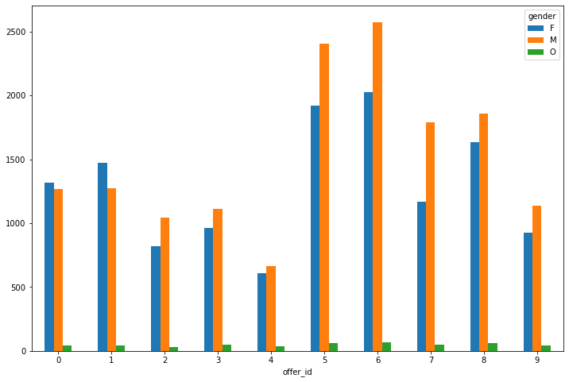

```python
groups_gender_offers = Starbucks_final_df[Starbucks_final_df['offer_id'] != 10].groupby(['gender', 'offer_id'])\
['success'].sum().unstack('gender').plot.bar(figsize = (12,8), rot=0)
```

Here is a more summarized plot:

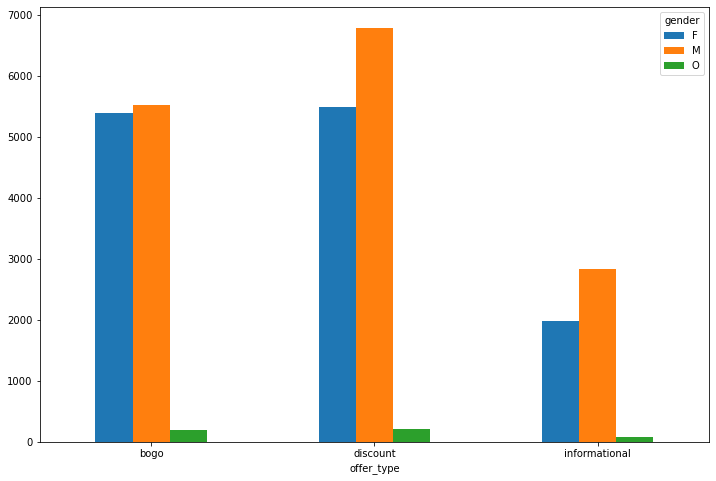

```python
groups_gender_offers = Starbucks_final_df[Starbucks_final_df['offer_type'] != 'none'].groupby(['gender', 'offer_type'])\
['success'].sum().unstack('gender').plot.bar(figsize = (12,8), rot=0)
```

##### Which offers are preferred according to income?

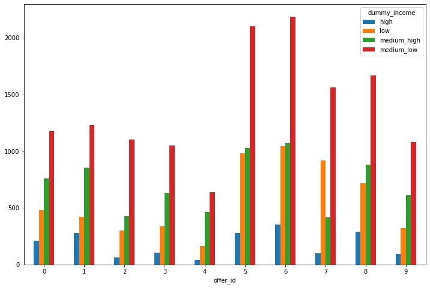

```python
groups_gender_offers = Starbucks_final_df[Starbucks_final_df['offer_id'] != 10].groupby(['dummy_income', 'offer_id'])\
['success'].sum().unstack('dummy_income').plot.bar(figsize = (12,8), rot=0)
```

There are not so many customers with high income. The target group is peoel who earn between 50 and 75k. for them, the most preffered offer ids are 5 and 6, in the table below we see they prefer discount offers.

Here is amore summarized table

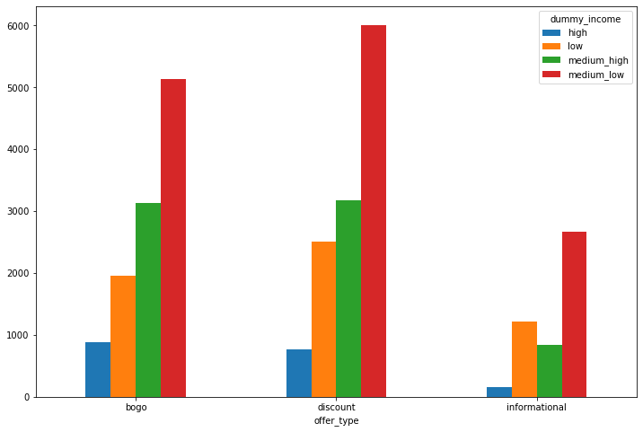

```python
groups_gender_offers = Starbucks_final_df[Starbucks_final_df['offer_id'] != 10].groupby(['dummy_income', 'offer_type'])\
['success'].sum().unstack('dummy_income').plot.bar(figsize = (12,8), rot=0)
```

##### Which offers are preferred according to age?

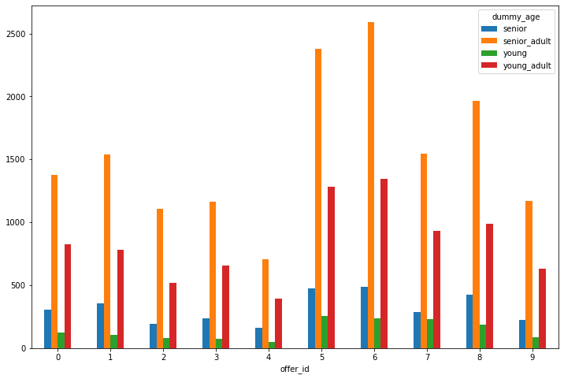

```python
groups_gender_offers = Starbucks_final_df[Starbucks_final_df['offer_id'] != 10].groupby(['dummy_age', 'offer_id'])\
['success'].sum().unstack('dummy_age').plot.bar(figsize = (12,8), rot=0)
```

Senior adults are the biggest clientele, and prefer offer ids 5 and 6, (discount type on the plotbelow) This leads me to think that most of them have also a medium low income.

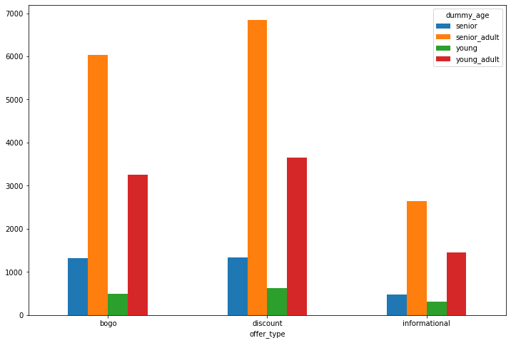

```python
groups_gender_offers = Starbucks_final_df[Starbucks_final_df['offer_id'] != 10].groupby(['dummy_age', 'offer_type'])\
['success'].sum().unstack('dummy_age').plot.bar(figsize = (12,8), rot=0)
```

##### Which offers are preferred according to date of becoming a member?

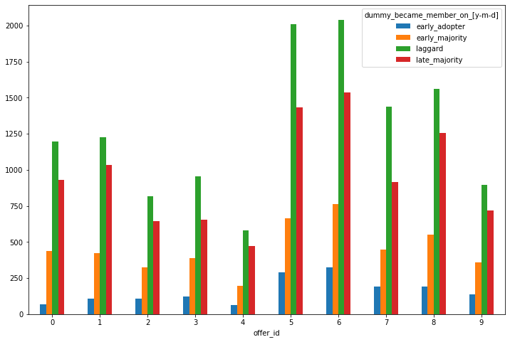

```python
groups_gender_offers = Starbucks_final_df[Starbucks_final_df['offer_id'] != 10].groupby(['dummy_became_member_on_[y-m-d]', 'offer_id'])\
['success'].sum().unstack('dummy_became_member_on_[y-m-d]').plot.bar(figsize = (12,8), rot=0)
```

This is something we could have expected, each offer has the same distribution, which leads ot think that time of becoming a member does not have an effect on which offers they might prefer.

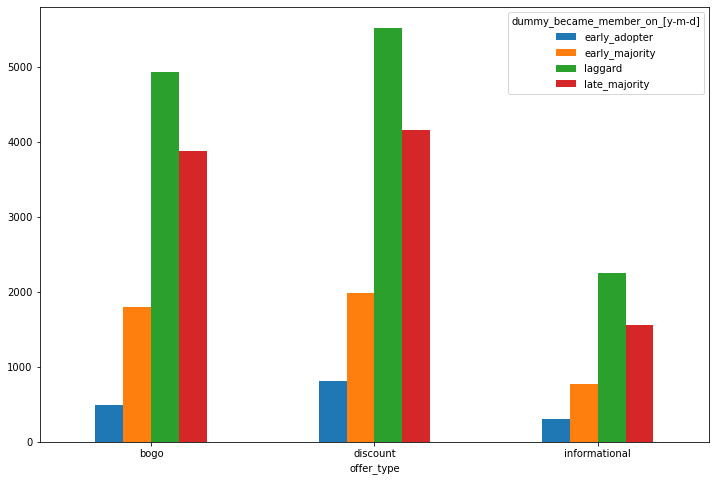

```python
groups_gender_offers = Starbucks_final_df[Starbucks_final_df['offer_id'] != 10].groupby(['dummy_became_member_on_[y-m-d]', 'offer_type'])\
['success'].sum().unstack('dummy_became_member_on_[y-m-d]').plot.bar(figsize = (12,8), rot=0)
```

##### Which are the most successful offers?

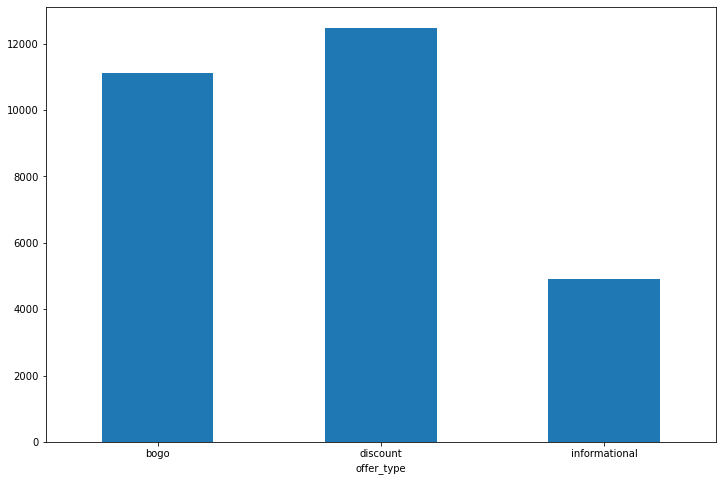

```python
groups_gender_offers = Starbucks_final_df[Starbucks_final_df['offer_type'] != 'none'].groupby(['offer_type'])\
                                         ['success'].sum()\
                                         .plot.bar(figsize = (12,8), rot=0)
```

The most successful offer type is discount.

##### Which are the most profitable offers?

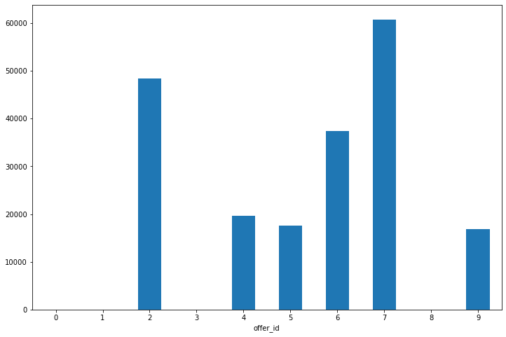

```python
groups_gender_offers = Starbucks_final_df[Starbucks_final_df['offer_type'] != 'none'].groupby(['offer_id'])\
                                         ['profit'].sum()\
                                         .plot.bar(figsize = (12,8), rot=0)
```

This plot must be taken with a grain of salt. Bogos are not profitable from our considerations as you produce 0 profit. But they serve other purposed and their success is measured not based on the profit. The most profitable offer is 7 and 2, these are informational. However, informational offers' profit is based on the spending in a period time, during which there were other offers as well. We could clearly conclude that offer 6 among discounts is the most profitable one.

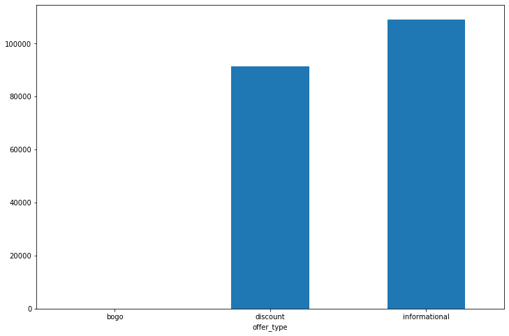

```python
groups_gender_offers = Starbucks_final_df[Starbucks_final_df['offer_type'] != 'none'].groupby(['offer_type'])\
                                         ['profit'].sum()\
                                         .plot.bar(figsize = (12,8), rot=0)
```

##### Which are the most profitable offers between informational?

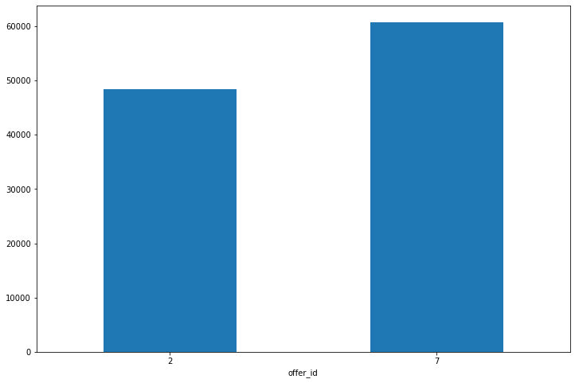

```python
groups_gender_offers = Starbucks_final_df[(Starbucks_final_df['offer_id'] == 2) | \
                                         (Starbucks_final_df['offer_id'] == 7)].groupby(['offer_id'])\
                                         ['profit'].sum()\
                                         .plot.bar(figsize = (12,8), rot=0)
```

##### How much money was earned in total with offers Vs. without offers?

```python
offer_profit = Starbucks_final_df[Starbucks_final_df['offer_id'] != 10].groupby(['offer_id'])['profit'].sum().sum()
```

```python
none_offer_profit = Starbucks_final_df[Starbucks_final_df['offer_id'] == 10].groupby(['offer_id'])['profit'].sum().sum()
```

```
<BarContainer object of 2 artists>
```

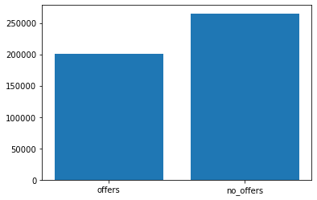

```python
y_values = [offer_profit, none_offer_profit]
x_values =  ['offers', 'no_offers']
plt.bar(x_values, y_values)
```

They have made more money without the offers

```python
Starbucks_final_df.to_pickle("./Starbucks_plotting.pkl")
```

#### Data cleansing

We will transform offer_id into dummies, as it is a categorical atribute.

Rewards, difficulty*[$], duration*[h] will be scaled between 0 and 1

```python
Starbucks_final_df['reward_[$]'] = (Starbucks_final_df['reward_[$]'] - Starbucks_final_df['reward_[$]'].min())/Starbucks_final_df['reward_[$]'].max()
```

```python
Starbucks_final_df['difficulty_[$]'] = (Starbucks_final_df['difficulty_[$]'] - Starbucks_final_df['difficulty_[$]'].min())/Starbucks_final_df['difficulty_[$]'].max()
```

```python
Starbucks_final_df['duration_[h]'] = (Starbucks_final_df['duration_[h]'] - Starbucks_final_df['duration_[h]'].min())/Starbucks_final_df['duration_[h]'].max()
```

```python
Starbucks_final_df.shape
```

```
(93277, 36)
```

```python
Starbucks_final_df = pd.get_dummies(Starbucks_final_df, prefix=['offer_id'], columns=['offer_id'])
```

Alright, so data has been scaled and categrical variables have been converted to dummies. But there are further considerations.

We are focused on offers, so we should eliminate the rows with offer ids = 10.

We will focus on the success variable, that will be our label for training.

We will delete viewed and completed because we know that would directly explain success.

Also we delete all dummies

```python
Starbucks_final_df = Starbucks_final_df.loc[Starbucks_final_df['offer_id_10'] != 1]
```

```python
Starbucks_final_df = Starbucks_final_df.drop(columns=['viewed'])
```

```python
Starbucks_final_df = Starbucks_final_df.drop(columns=['completed'])
```

```python
Starbucks_final_df = Starbucks_final_df.drop(columns=['offer_id_10'])
```

```python
Starbucks_final_df = Starbucks_final_df.drop(columns=['dummy_age'])
```

```python
Starbucks_final_df = Starbucks_final_df.drop(columns=['offer_type'])
```

```python
Starbucks_final_df = Starbucks_final_df.drop(columns=['dummy_became_member_on_[y-m-d]'])
```

```python
Starbucks_final_df = Starbucks_final_df.drop(columns=['dummy_income'])
```

```python
Starbucks_final_df = Starbucks_final_df.drop(columns=['gender'])
```

```python
Starbucks_final_df = Starbucks_final_df.drop(columns=['customer_id'])
```

```python
Starbucks_final_df = Starbucks_final_df.drop(columns=['profit'])
```

###### Save the final dataset into a pickle file

```python
Starbucks_final_df.to_pickle("./Starbucks_modelling_df.pkl")
```

### 4. Modeling

```python
Starbucks_modelling_df = pd.read_pickle("./Starbucks_modelling_df.pkl")
```

```python
Starbucks_modelling_df
```

|  | success | missing_values | gender_F | gender_M | gender_O | reward_[$] | difficulty_[$] | duration_[h] | offer_type_bogo | offer_type_discount | ... | offer_id_0 | offer_id_1 | offer_id_2 | offer_id_3 | offer_id_4 | offer_id_5 | offer_id_6 | offer_id_7 | offer_id_8 | offer_id_9 |
| --- | --- | --- | --- | --- | --- | --- | --- | --- | --- | --- | --- | --- | --- | --- | --- | --- | --- | --- | --- | --- | --- |
| 0 | 1 | 0 | 1 | 0 | 0 | 1.0 | 0.5 | 0.7 | 1 | 0 | ... | 1 | 0 | 0 | 0 | 0 | 0 | 0 | 0 | 0 | 0 |
| 1 | 0 | 1 | 0 | 1 | 0 | 1.0 | 0.5 | 0.7 | 1 | 0 | ... | 1 | 0 | 0 | 0 | 0 | 0 | 0 | 0 | 0 | 0 |
| 2 | 1 | 1 | 1 | 0 | 0 | 1.0 | 0.5 | 0.7 | 1 | 0 | ... | 1 | 0 | 0 | 0 | 0 | 0 | 0 | 0 | 0 | 0 |
| 3 | 0 | 1 | 0 | 1 | 0 | 1.0 | 0.5 | 0.7 | 1 | 0 | ... | 1 | 0 | 0 | 0 | 0 | 0 | 0 | 0 | 0 | 0 |
| 4 | 0 | 0 | 1 | 0 | 0 | 1.0 | 0.5 | 0.7 | 1 | 0 | ... | 1 | 0 | 0 | 0 | 0 | 0 | 0 | 0 | 0 | 0 |
| ... | ... | ... | ... | ... | ... | ... | ... | ... | ... | ... | ... | ... | ... | ... | ... | ... | ... | ... | ... | ... | ... |
| 76272 | 0 | 0 | 0 | 1 | 0 | 0.2 | 0.5 | 0.7 | 0 | 1 | ... | 0 | 0 | 0 | 0 | 0 | 0 | 0 | 0 | 0 | 1 |
| 76273 | 0 | 1 | 0 | 1 | 0 | 0.2 | 0.5 | 0.7 | 0 | 1 | ... | 0 | 0 | 0 | 0 | 0 | 0 | 0 | 0 | 0 | 1 |
| 76274 | 0 | 0 | 1 | 0 | 0 | 0.2 | 0.5 | 0.7 | 0 | 1 | ... | 0 | 0 | 0 | 0 | 0 | 0 | 0 | 0 | 0 | 1 |
| 76275 | 0 | 0 | 0 | 1 | 0 | 0.2 | 0.5 | 0.7 | 0 | 1 | ... | 0 | 0 | 0 | 0 | 0 | 0 | 0 | 0 | 0 | 1 |
| 76276 | 0 | 0 | 0 | 1 | 0 | 0.2 | 0.5 | 0.7 | 0 | 1 | ... | 0 | 0 | 0 | 0 | 0 | 0 | 0 | 0 | 0 | 1 |

76277 rows × 36 columns

Everything is ready to input our dataset into the model.

```python
labels = Starbucks_modelling_df['success']
features = Starbucks_modelling_df.drop(columns=['success'], inplace=False)
```

```python
# Split the 'features' and 'income' data into training and testing sets
X_train, X_test, y_train, y_test = train_test_split(features,
                                                    labels,
                                                    test_size = 0.3,
                                                    random_state = 42)

# Show the results of the split
print("Training set has {} samples.".format(X_train.shape[0]))
print("Testing set has {} samples.".format(X_test.shape[0]))
```

```
Training set has 53393 samples.
Testing set has 22884 samples.
```

For classification, we will use:

- SVM
- Random forests
- Logistic regression
- Gradient Boosting

```python
from sklearn.svm import SVC
from sklearn.ensemble import RandomForestClassifier
from sklearn.linear_model import LogisticRegression
from sklearn.ensemble import GradientBoostingClassifier
```

```python
# REF: udavity course
# TODO: Import two metrics from sklearn - fbeta_score and accuracy_score
from sklearn.metrics import fbeta_score, accuracy_score

def train_predict(learner, sample_size, X_train, y_train, X_test, y_test):
    '''
    inputs:
       - learner: the learning algorithm to be trained and predicted on
       - sample_size: the size of samples (number) to be drawn from training set
       - X_train: features training set
       - y_train: income training set
       - X_test: features testing set
       - y_test: income testing set
    '''

    results = {}

    # TODO: Fit the learner to the training data using slicing with 'sample_size' using .fit(training_features[:], training_labels[:])
    start = time() # Get start time
    learner = learner.fit(X_train[:sample_size], y_train[:sample_size])
    end = time() # Get end time

    # TODO: Calculate the training time
    results['train_time'] = end - start

    # TODO: Get the predictions on the test set(X_test),
    #       then get predictions on the first 300 training samples(X_train) using .predict()
    start = time() # Get start time
    predictions_test = learner.predict(X_test)
    predictions_train = learner.predict(X_train[:300])
    end = time() # Get end time

    # TODO: Calculate the total prediction time
    results['pred_time'] = end - start

    # TODO: Compute accuracy on the first 300 training samples which is y_train[:300]
    results['acc_train'] = accuracy_score(y_train[:300], predictions_train)

    # TODO: Compute accuracy on test set using accuracy_score()
    results['acc_test'] = accuracy_score(y_test, predictions_test)

    # TODO: Compute F-score on the the first 300 training samples using fbeta_score()
    results['f_train'] = fbeta_score(y_train[:300], predictions_train, beta=0.5)

    # TODO: Compute F-score on the test set which is y_test
    # I use beta = 0.5 as we are focuing on precision
    results['f_test'] = fbeta_score(y_test, predictions_test, beta=0.5)


    # Success
    print("{} trained on {} samples.".format(learner.__class__.__name__, sample_size))

    # Return the results
    return results
```

```python
clf_A = SVC(random_state=0)
clf_B = RandomForestClassifier(random_state=0)
clf_C = LogisticRegression(random_state=0)
clf_D = GradientBoostingClassifier(random_state=0)
```

```python
clfs = [clf_A, clf_B, clf_C, clf_D]
```

```python
# initialize the progress bar
bar_1 = progressbar.ProgressBar(maxval=len(clfs), \
    widgets=[progressbar.Bar('=', '[', ']'), ' ', progressbar.Percentage()])

# initialize the progress bar
bar_2 = progressbar.ProgressBar(maxval=2, \
    widgets=[progressbar.Bar('=', '[', ']'), ' ', progressbar.Percentage()])

# REF: udacity course
# It is interesting to see how they perform with less samples
samples_100 = int(len(y_train))
samples_10 = int(round(0.1 * samples_100))

# Collect results on the learners
results = {}
bar_1.start()
clf_counter = 0
for clf in clfs:
    clf_name = clf.__class__.__name__
    results[clf_name] = {}
    bar_2.start()
    for i, samples in enumerate([samples_10, samples_100]):
        results[clf_name][i] = \
        train_predict(clf, samples, X_train, y_train, X_test, y_test)

        # progress bar
        bar_2.update(i+1)
        sleep(0.1)

    bar_2.finish()
   # progress bar
    clf_counter += 1
    bar_1.update(clf_counter)
    sleep(0.1)

bar_1.finish()
```

```
SVC trained on 5339 samples.
```

```
SVC trained on 53393 samples.
```

```
RandomForestClassifier trained on 5339 samples.
```

```
[====================================                                    ]  50%
```

```
RandomForestClassifier trained on 53393 samples.
```

```
LogisticRegression trained on 5339 samples.
```

```
[======================================================                  ]  75%
```

```
LogisticRegression trained on 53393 samples.
```

```
[====================================                                    ]  50%
```

```
GradientBoostingClassifier trained on 5339 samples.
```

```
[========================================================================] 100%
```

```
GradientBoostingClassifier trained on 53393 samples.
```

```
[========================================================================] 100%
```

```python
# Run metrics visualization for the three supervised learning models chosen
ALL_results = {}
ALL_results = results
```

##### Performing algorithm comparisons

```python
# We print the different metrics for all the tested algorithms.
print('Training with all samples')
for clf in clfs:
    clf_name = clf.__class__.__name__
    print(clf_name)
    print('Training time = ', ALL_results[clf_name][1]['train_time'])
    print('Testing time = ', ALL_results[clf_name][1]['pred_time'])
    print('Test Accuracy = ', ALL_results[clf_name][1]['acc_test'])
    print('Test Fscore = ', ALL_results[clf_name][1]['f_test'])
    print('\n')
```

```
Training with all samples
SVC
Training time =  164.17853903770447
Testing time =  33.015408754348755
Test Accuracy =  0.6959884635553225
Test Fscore =  0.582545208095869


RandomForestClassifier
Training time =  0.2846059799194336
Testing time =  0.0351099967956543
Test Accuracy =  0.7047718930256948
Test Fscore =  0.5984216117772044


LogisticRegression
Training time =  0.16101694107055664
Testing time =  0.0060138702392578125
Test Accuracy =  0.7007953155042824
Test Fscore =  0.5910921218455107


GradientBoostingClassifier
Training time =  4.785567045211792
Testing time =  0.03660392761230469
Test Accuracy =  0.7081803880440483
Test Fscore =  0.6026470491641762
```

- Best train time: LogisticRegression
- Best test time: LogisticRegression
- Best Accuracy: GradientBoostingClassifier (by a hair)
- Best Fscore (beta = 0.5): GradientBoostingClassifier (by a hair)

```python
# We print the different metrics for all the tested algorithms.
print('Training with 10% of samples')
for clf in clfs:
    clf_name = clf.__class__.__name__
    print(clf_name)
    print('Training time = ', ALL_results[clf_name][0]['train_time'])
    print('Testing time = ', ALL_results[clf_name][0]['pred_time'])
    print('Test Accuracy = ', ALL_results[clf_name][0]['acc_test'])
    print('Test Fscore = ', ALL_results[clf_name][0]['f_test'])
    print('\n')
```

```
Training with 10% of samples
SVC
Training time =  1.0258140563964844
Testing time =  3.1299290657043457
Test Accuracy =  0.6952455864359378
Test Fscore =  0.5777104623680969


RandomForestClassifier
Training time =  0.0488131046295166
Testing time =  0.033370018005371094
Test Accuracy =  0.673527355357455
Test Fscore =  0.5574165715010785


LogisticRegression
Training time =  0.021611928939819336
Testing time =  0.008096933364868164
Test Accuracy =  0.6955514770145079
Test Fscore =  0.5839501477428981


GradientBoostingClassifier
Training time =  0.4492828845977783
Testing time =  0.0361332893371582
Test Accuracy =  0.701800384548156
Test Fscore =  0.5943984313266412
```

- Best train time: LogisticRegression
- Best test time: LogisticRegression
- Best Accuracy: GradientBoostingClassifier (by a hair)
- Best Fscore (beta = 0.5): GradientBoostingClassifier (by a hair)

```python
# We save the model
filename = 'trained_classifier.sav'
pickle.dump(clf_D, open(filename, 'wb'))
```

```python
loaded_model = pickle.load(open(filename, 'rb'))
```

The most performant classifier is GradientBoosting. We will use it and now try to optimize its parameters for getting a better accuracy and fscore.

Before we do that, let us get some intuition of the guts of the model afteer training

This is the feature that has the biggest impact on the classification for success

```python
best_feature_index = np.where(loaded_model.feature_importances_ == loaded_model.feature_importances_.max())
features.columns[best_feature_index]
```

```
Index(['channel_social'], dtype='object')
```

##### Grid search on best performing algorithm

```python
from sklearn.metrics import make_scorer
from sklearn.model_selection import GridSearchCV
```

```python
loaded_model
```

```
GradientBoostingClassifier(criterion='friedman_mse', init=None,
                           learning_rate=0.1, loss='deviance', max_depth=3,
                           max_features=None, max_leaf_nodes=None,
                           min_impurity_decrease=0.0, min_impurity_split=None,
                           min_samples_leaf=1, min_samples_split=2,
                           min_weight_fraction_leaf=0.0, n_estimators=100,
                           n_iter_no_change=None, presort='auto',
                           random_state=0, subsample=1.0, tol=0.0001,
                           validation_fraction=0.1, verbose=0,
                           warm_start=False)
```

```python
# TODO: Initialize the classifier again
GradientBoostingClassifier_optimal =  GradientBoostingClassifier()
```

```python
# Create the parameters list you wish to tune, using a dictionary if needed.
def grid_search(model, scorer):

    # specify parameters for grid search
    parameters = {
        'learning_rate': [0.1, 0.5, 1],
        'max_depth': [3, 4],
        'n_estimators': [100, 125, 150],
    }

    # create grid search object
    cv = GridSearchCV(model, param_grid=parameters, scoring=scorer)

    return cv
```

```python
# fbeta_score scoring object using make_scorer()
scorer = make_scorer(fbeta_score, beta=0.5)
```

```python
# Perform grid search on the classifier using 'scorer' as the scoring method using GridSearchCV()
grid_object = grid_search(GradientBoostingClassifier_optimal, scorer)
```

```python
# Fit the grid search object to the training data
grid_fit = grid_object.fit(X_train, y_train)
```

```python
# Get the estimator
best_clf = grid_fit.best_estimator_
```

```python
# We save the model
filename = 'best_trained_classifier.sav'
pickle.dump(best_clf, open(filename, 'wb'))
```

```python
best_clf = pickle.load(open(filename, 'rb'))
```

```python
# Make predictions using the unoptimized and model
predictions = (clf.fit(X_train, y_train)).predict(X_test)
best_predictions = best_clf.predict(X_test)
```

```python
# Report the before-and-afterscores
print("Unoptimized model\n------")
print("Accuracy score on testing data: {:.4f}".format(accuracy_score(y_test, predictions)))
print("F-score on testing data: {:.4f}".format(fbeta_score(y_test, predictions, beta = 0.5)))
print("\nOptimized Model\n------")
print("Final accuracy score on the testing data: {:.4f}".format(accuracy_score(y_test, best_predictions)))
print("Final F-score on the testing data: {:.4f}".format(fbeta_score(y_test, best_predictions, beta = 0.5)))
best_clf
```

```
Unoptimized model
------
Accuracy score on testing data: 0.7082
F-score on testing data: 0.6026

Optimized Model
------
Final accuracy score on the testing data: 0.7105
Final F-score on the testing data: 0.6086
```

```
GradientBoostingClassifier(criterion='friedman_mse', init=None,
                           learning_rate=0.5, loss='deviance', max_depth=3,
                           max_features=None, max_leaf_nodes=None,
                           min_impurity_decrease=0.0, min_impurity_split=None,
                           min_samples_leaf=1, min_samples_split=2,
                           min_weight_fraction_leaf=0.0, n_estimators=100,
                           n_iter_no_change=None, presort='auto',
                           random_state=None, subsample=1.0, tol=0.0001,
                           validation_fraction=0.1, verbose=0,
                           warm_start=False)
```

### 5. Evaluation

#### Result evaluation

The best model to predict if an offer will be successful is Gradient Boosting. However, 70% is not such a high accuracy, better than human though. Grid search did not show much improvements, so furtehr tunning should be carried out. We saw that the learning rate went from 0.1 to 0.5, while the rest of parameters stayed the same. The enxt logical step would be to try with a learning rate of 0.75 (as 1 was not chosen) and try to change other parameters.

#### Outlook

With respect to the model, we could perform further tuning to improve the scores. Overall, the score is not too high but of course, it is better than human intuition as there are many parameters into consideration.

### 6. Deployment

Process and results presented in blogpost.

#### Conclusion

We have wrangled, cleansed and explored 3 datasets. We have studied individually their content. We have calculated the target label for the model, the success of an offer. We have merged afterwards all these datasets, further explore its insights and finally, prepare it and feed it into a model. The model chosen was Gradient Boosting and teh accuracy and f-score were 0.7 and 0.6 respectively, which are not too high but given the amount of variables, it is a better prediction than a 1/offer_ids of a human.